# Analyse des Communautées d’amphibiens - Maîtrise en biologie

Author

Claudie Bouffard

**IMPORTANT:** Les codes suivants ont été générés à l’aide de ChatGPT (GPT-5.6 Luna par OpenAI, 2026) et le support d’Angélique Dupuch et Katrine Turgeon.

## Glossaire :

### Liste d’espèces sélectionnées :

- **Ambystoma :** Salamandres du genre *Ambystoma*. Les espèces présentes au Québec, la salamandre maculée (*A. maculatum*), la salamandre à points bleues (*A. laterale*) et/ou salamandres du complexe de Jerfferson (*A. jeffersonianum complex*), sont incluses dans cette étude. Celles-ci sont toutes des espèces concidérées comme dépendantes des étangs vernaux et qui partagent un cycle de vie similaires.
- **LISY :** Grenouille des bois (Lithobates sylvaticus). Espèce dépendante des étangs vernaux.
- **LICL :** Grenouille verte (*Lithobates clamitans*). Espèce associée aux habitats à canopées ouvertes et étangs permanents. Représente de la compétition/prédateur pour les espèces dépendantes des étangs vernaux.
- **PSCR :** Rainette cucifère (Pseudacris crucifer). Espèce versatile et non-prédatrice des espèces dépendantes des étangs vernaux.

### Liste de type de traitements:

- **PEH :** Plantation de peuplier hybrides sur monticule (entre 1 à 5 ans). Les arbres sont trop jeunes pour avoir un effet sur l’hydrologie par evapotranspiration. Canopée particulièrement ouverte car les arbres sont petits.
- **CPPTM :** Coupe avec Protection des Petites Tiges Marchandes. Similaire à la coupe totale mais certains jeunes arbres sont laissés sur place. Ceux-ci ont tendance à tomber avec le vent. Sur les terres de DOMTAR, cette pratique est majoritairement dans des peuplements résineux mais a été vu dans du feuillus
- **CJ :** Coupe de Jardinage. Coupe qui imite le régime de trouée naturel des forêts de feuillus matures. Cela n’empêche la dégradation du sol par les ornières de machinerie. La canopée reste fermée.
- **NAT:** Étangs vernaux sélectionnées dans des milieux protégés depuis au moins 70 ans. Celui-ci représente le contrôle pour mon étude.

## Est-ce qu’il y a un problème de dépendance entre les étangs?

Avant de commencer l’analyse, il est important de déterminer si les étangs étudiés sont indépendants puisqu’une potentielle dépendance pourrait influencer mon choix de tests à effectuer.  
Le design expérimental de cette étude place plusieurs étangs en paires. Environ 14 paires d’étangs partagent le même peuplement. Ainsi, certains étangs sont séparés de quelques mètres seulement. Ceux-ci auraient donc le potentiel de partager les mêmes conditions environnementales ou la même communauté d’amphibiens. Cette relation a le potentiel de brouiller le résultats de mes autres analyses, particulièrement puisque ma base de donnée est petite (que 57 étangs au total) :

[figure not shown]

Bien que certains étangs partagent les mêmes peuplements, d’autres sont fortements éloignés les uns des autres (plusieurs kilomètres) puisque les sites d’étude sont séparés en différentes régions (Watopeka, Dorset et plus de 3 Parcs de la SÉPAC). Ceci peu compliquer les tests de Moran’s I qui requiert de déterminer le nombre de plus proche voisin (k).

[figure not shown]

Face à cette situation, plusieurs tests ont été effectués pour avoir la meilleure image que possible de la dépendance/indépendance des paires d’étangs se trouvant dans les mêmes peuplements.  
À noter que les paires d’étangs partagent les mêmes traitements sylvicoles. De base, ils ont plus de chances de se ressembler. Ainsi, pour éviter de potentiel biais, les analyses suivantes prennent aussi en compte de l’effet des traitements sylvicoles sur les étangs. Ceci sera exploré plus en détails dans les sections ci-bas.

### Analyse de sensibilité par Permutation - Valeurs environnementales quantitatives :

En théorie, si certains étangs sont a proximité, l’environnement devrait être fortement similaire. Pour tester cette théorie, essayons de répondre à la question suivante:  
**Les deux étangs qui forment une vraie paire sont-ils plus semblables entre eux que ce qu’on observerait si on formait aléatoirement des paires d’étangs appartenant aux mêmes traitements?**

Premièrement, il faut préparer les données

```r
library(readxl)
library(dplyr)

df4 <-read_excel("C:/Users/super/Université du Québec en Outaouais/CLAUDIE ÉTANGS VERNAUX - Documents/Stats/Structure_des_communautes/Data_Base_presenceV7.xlsx", sheet = 1)
df4$Ph_moy <- as.numeric(df4$Ph_moy)
df4$Temp_moy <- as.numeric(df4$Temp_moy)
df4$superficie <- as.numeric(df4$superficie)
df4$volume <- as.numeric(df4$volume)
df4$Ouverture <- as.numeric(df4$Ouverture)
df4
```

```
# A tibble: 57 × 17
   No_etang   ambystoma  LICL  LISY  PSCR Traitement Ph_moy Temp_moy superficie
   <chr>          <dbl> <dbl> <dbl> <dbl> <chr>       <dbl>    <dbl>      <dbl>
 1 1WATCJ6            0     0     1     0 CJ           6.64     15.0    165000
 2 2WATCJ5            1     0     1     0 CJ           6.58     16.6    434700
 3 3WATCJ1            1     0     0     0 CJ           6.44     12.0     26600
 4 4WATCJ2            1     0     0     0 CJ           6.62     17.7    380800
 5 5WATCJ4            1     0     1     0 CJ           6.38     18.6     72000
 6 6WATCJ3            1     0     1     1 CJ           6.26     18.5    240000
 7 17WATPEH10         0     0     1     0 PEH          6.49     22.2     62059.
 8 7WATPEH2           0     0     1     1 PEH          6.33     15.6    267285.
 9 12WATPEH5          0     0     1     1 PEH          6.32     17.5    574453.
10 8WATPEH1           0     0     1     1 PEH          6.49     13.9    133706.
# ℹ 47 more rows
# ℹ 8 more variables: volume <dbl>, Ouverture <dbl>, Debris_in <chr>,
#   Debris_out <chr>, Hydro <chr>, Paires <dbl>, X <dbl>, Y <dbl>
```

```r
env_quanti <- df4[, c("Ph_moy","Temp_moy","superficie","volume","Ouverture")]
```

Plusieurs composantes de l’environnement sont quantitative, alors nous allons commencer avec ceux-ci. Pour faciliter la tâche, j’ai fait une fonction pour analyser automatiquement par permutation (9999 fois) chaque valeurs environnementales. Ceci a été créé avec l’aide de ChatGPT:

```r
similarite_paire <- function(df4, variable, nperm = 9999) {
  #________________________________________________________________
  #1.Garder uniquement les vraies paires

  tab <- table(df4$Paires)
  vraies_paires <- names(tab[tab == 2])
  #Identifie les numéros de paires qui apparaissent exactement 2 fois (les paires géographiquement proches)
  df_vraies_paires <- df4[df4$Paires %in% vraies_paires, ]
  #Retire tous les sites qui ne sont pas de ''vraies paires'' géographiques

  #________________________________________________________________
  #2. Valeurs observées entre les vraies paires

  observ <- df_vraies_paires |>
    dplyr::group_by(Paires) |>
    #Regroupe les données selon leur numéro de paires pour les traiter séparément
    dplyr::summarise(
      Traitement = first(Traitement),
      #Identifie le traitement de chaque paire
      diff = abs(diff(.data[[variable]])),
      #Calcule la différence absolue entre les paires (petite différence = similaire)
      .groups = "drop"
    )
  moyenne_observee <- mean(observ$diff)
  #calcule la différence moyenne entre toutes les vraies paires

  n_paires_traitement <- table(observ$Traitement)
  # Nombre de vraies paires dans chaque traitement

  #_________________________________________________________________
  #3. Permutations des paires aléatoires

  resultats_perm <- numeric(nperm)
  #Objet pour contenir toutes les permutations

  #Boucle qui dicte ce qui doit être répété 9 999 fois
  for(i in 1:nperm) {

    differences_perm <- c()
    #Objet pour contenir les différences de chaque paires aléatoires

    for (trait in names(n_paires_traitement)) {
    #Boucle qui passe à travers chaque traitement pour faire les permutations séparément. Permet de choisir aléatoirement seulement des étangs qui partagent les mêmes traitements.

      valeurs <- df4[[variable]][
        df4$Traitement == trait &
          !is.na(df4[[variable]])
      ]
      #Récupère la valeur environnementale souhaitée de ce traitement sauf un NA

      n_paires <- n_paires_traitement[trait]
      #Détermine le nombre de paires aléatoire à faire par traitement pour que ce soit le même nombre que les vrais paires

      n_etangs <- n_paires * 2
      #Nombre d'étangs nécessaires pour faire une paire

      valeurs_choisies <- sample(
        valeurs,
        size = n_etangs,
        replace = FALSE
      ) #Choisir des étangs au hasard sans choisir deux fois le même étang

      groupes <- rep(
        1:n_paires,
        each = 2
      ) #Groupe les paires aléatoires choisies

      diffs <- tapply(
        valeurs_choisies,
        groupes,
        function(x) abs(diff(x))
      ) #Calcule les différences entre les paires aléatoires

      differences_perm <- c(
        differences_perm,
        diffs
      ) #Regroupe toutes les différences des paires aléatoires de tous les traitements
    }

    resultats_perm[i] <- mean(differences_perm)
    #Calcule la différence moyenne des paires aléatoires
  }

  #_______________________________________________________________
  #4. p-value :

  p <- (sum(resultats_perm <= moyenne_observee) + 1) /
    (nperm + 1)
  #Compare moyenne observée des vraies paires avec les paires aléatoires.
  #Répond à la question: ''Parmi toutes mes paires aléatoires, combien ont une différence moyenne aussi petite ou encore plus petite que celle observée dans mes vraies paires?''. Le +1 est une correction utilisé pour les tests par permutations

  #_________________________________________________________________
  #5. Ce que la fonction va donner comme résultats

  list(
    variable = variable,
    difference_observee = moyenne_observee,
    p = p,
    permutations = resultats_perm,
    observations = observ
  )
}
```

Avec cette fonction, toutes les variables quantitatives sont testées:

1. **Température :**

   ```r
   set.seed(123)
   test_temp <- similarite_paire(df4,"Temp_moy")
   test_temp$difference_observee #1.504286
   ```

   ```
   [1] 1.504286
   ```

   ```r
   test_temp$p # 0.0615 NON SIGNIFICATIF Ici, les paires ne se ressemblent pas, plutôt indépendants alors
   ```

   ```
   [1] 0.0615
   ```

   Le p-value montre que les vraies paires a tendance à reflétes le hasard. Suggère l’indépendance des vraies paires
2. **Superficie :**

   ```r
   test_sup <- similarite_paire(df4,"superficie")
   test_sup$difference_observee
   ```

   ```
   [1] 340403.2
   ```

   ```r
   test_sup$p
   ```

   ```
   [1] 0.5013
   ```

   ```r
   df4$log_superficie <- log10(df4$superficie)
   test_suplog <- similarite_paire(df4,"log_superficie")
   test_suplog$difference_observee
   ```

   ```
   [1] 0.3793152
   ```

   ```r
   test_suplog$p
   ```

   ```
   [1] 0.136
   ```

   Le p-value montre que les vraies paires reflétes le hasard. Suggère l’indépendance des vraies paires
3. **Volume :**

   ```r
   test_volume <- similarite_paire(df4,"volume")
   test_volume$difference_observee
   ```

   ```
   [1] 177053.1
   ```

   ```r
   test_volume$p
   ```

   ```
   [1] 0.686
   ```

   ```r
   df4$log_volume <- log10(df4$volume)
   test_volumelog <- similarite_paire(df4,"log_volume")
   test_volumelog$difference_observee
   ```

   ```
   [1] 0.4120509
   ```

   ```r
   test_volumelog$p
   ```

   ```
   [1] 0.052
   ```

   Le p-value montre que les vraies paires reflétes le hasard. Suggère l’indépendance des vraies paires
4. **Ouverture de la canopée :**

   ```r
   test_ouverture <- similarite_paire(df4,"Ouverture")
   test_ouverture$difference_observee
   ```

   ```
   [1] 9.475
   ```

   ```r
   test_ouverture$p
   ```

   ```
   [1] 0.0038
   ```

   Le p-value montre une forte similarité entre les vraies paires. Suggère une dépendance entre les vraies paires.
5. **pH :**

   ```r
   set.seed(123)
   test_ph <- similarite_paire(df4,"Ph_moy", nperm = 9999)
   test_ph$difference_observee
   ```

   ```
   [1] 0.1978571
   ```

   ```r
   test_ph$p
   ```

   ```
   [1] 1e-04
   ```

   Le p-value montre une forte similarité entre les vraies paires. Suggère une dépendance entre les vraies paires.

### Analyse de sensibilité - Valeurs environnementales qualitatives :

Maintenant, certaines des données sont qualitatives. L’hydropériode est binaire et les débris ont trois catégories. Alors, ils seront gérés in peu différement. Mais, en général on veut répondre à la question:  
**Les deux étangs qui forment une vraie paire sont-ils plus semblables entre eux que ce qu’on observerait si on formait aléatoirement des paires d’étangs appartenant aux mêmes traitements?**

1. **Hydropériode :**

   Note que la fonction est similaire que ce qui a été fait précédement. Ici, je vais détailler que ce qui a été ajouté/modifié

   ```r
   test_hydro <- function(df4, nperm = 9999) {

     #________________________________________________________________
     #1.Garder uniquement les vraies paires

     tab <- table(df4$Paires)
     vraies_paires <- names(tab[tab == 2])
     df_vraies_paires <- df4[df4$Paires %in% vraies_paires, ]

     #___________________________________________________________________________
     #2. Proportion des vraies paires qui ont une hydrologie similaire

     observ <- df_vraies_paires |>
       dplyr::group_by(Paires) |>
       dplyr::summarise(
         Traitement = first(Traitement),
         meme_hydro = n_distinct(Hydro) == 1,
         #Une paire d'étangs peu avoir qu'une seule catégorie (hum-hum et sec-sec) ou peu avoir 2 catégories (hum-sec et sec-hum). Si une catégorie, ça va ressortir TRUE (1==1) si 2 catégories (2==1) ça va ressortir FALSE. Ça permet de déterminer si les paire sont similaires ou non.
         .groups = "drop"
       )

     proportion_observee <- mean(observ$meme_hydro)
     #Probabilité moyenne d'avoir les mêmes catégories (TRUE)

     n_paires_traitement <- table(observ$Traitement)

     #__________________________________________________________________________
     #3. Permutations des paires aléatoires
     resultats_perm <- numeric(nperm)

     for(i in 1:nperm) {

       similarites_perm <- c()
       for(trait in names(n_paires_traitement)) {

         valeurs <- df4$Hydro[
           df4$Traitement == trait &
             !is.na(df4$Hydro)
         ]

         n_paires <- n_paires_traitement[trait]

         n_etangs <- n_paires * 2

         valeurs_choisies <- sample(
           valeurs,
           size = n_etangs,
           replace = FALSE
         )

         groupes <- rep(
           1:n_paires,
           each = 2
         )

         meme <- tapply(
           valeurs_choisies,
           groupes,
           function(x) length(unique(x)) == 1
         )
         #Vérifier si les deux étangs de chaque paire ont la même Hydropériode (TRUE ou FALSE)

         similarites_perm <- c(
           similarites_perm,
           meme
         ) #Ajouter les résultats pour le traitement puis passe au prochain traitement
       }

       resultats_perm[i] <- mean(similarites_perm)
       # Proportion moyenne de paires aléatoires ayant le même Hydropériode (TRUE)
     }

     #______________________________________________________________________
     #4. P-value - Test unilatéral (on s'attend que les étangs qui sont près les uns des autres aient une hydropériode similaire)
     p <- (sum(resultats_perm >= proportion_observee) + 1) /
       (nperm + 1)
     #Combien des 9 999 simulations ont la même proportion des vraies paires ou une plus grande proportion d'hydropériode pareil que les vraies paires

     #_____________________________________________________________
     #5. Résultats de la fonction
     list(
       proportion_observee = proportion_observee,
       p = p,
       permutations = resultats_perm,
       observations = observ
     )
   }
   ```

   Avec cette fonction, il est possible de tester les valeures de ma base de donnée:

   ```r
   set.seed(123)
   test_sim_hydro <- test_hydro(df4,nperm = 9999)
   test_sim_hydro$proportion_observee #0.8571429 donc 85,7 % des paires ont la même catégorie.
   ```

   ```
   [1] 0.8571429
   ```

   ```
   [1] 0.0681
   ```

   La question à répondre:  
   **À l’intérieur de chaque traitement, les étangs d’une même paire ont-ils plus souvent la même catégorie de débris que ce qu’on obtiendrait en formant aléatoirement des paires parmi tous les étangs du même traitement?**

   Note que la fonction est similaire que ce qui a été fait précédement. Ici, je vais détailler que ce qui a été ajouté/modifié, mais la formule est très similaire à celle pour l’hydropériode

   ```r
   similarite_debris <- function(df4, variable, nperm = 9999) {

     #________________________________________________________________
     #1.Garder uniquement les vraies paires
     tab <- table(df4$Paires)
     vraies_paires <- names(tab[tab == 2])
     df_vraies_paires <- df4[df4$Paires %in% vraies_paires, ]

    #___________________________________________________________________________
     #2. Proportion des vraies paires qui ont une catégorie de débris similaire
     observ <- df_vraies_paires |>
       dplyr::group_by(Paires) |>
       dplyr::summarise(
         Traitement = first(Traitement),
         meme_debris = n_distinct(.data[[variable]]) == 1,
         #Le seul vrai changement est ici, ça rend la fonction plus générique pour mettre ''Debris_in'' ou ''Debris_out''
         .groups = "drop"
       )

     proportion_observee <- mean(observ$meme_debris)

     n_paires_traitement <- table(observ$Traitement)

     #__________________________________________________________________________
     #3. Permutations des paires aléatoires
     resultats_perm <- numeric(nperm)

     for(i in 1:nperm) {
       similarites_perm <- c()

       for(trait in names(n_paires_traitement)) {

         valeurs <- df4[[variable]][
           df4$Traitement == trait &
             !is.na(df4[[variable]])
         ]

         n_paires <- n_paires_traitement[trait]

         n_etangs <- n_paires * 2

         valeurs_choisies <- sample(
           valeurs,
           size = n_etangs,
           replace = FALSE
         )

         groupes <- rep(
           1:n_paires,
           each = 2
         )

         meme <- tapply(
           valeurs_choisies,
           groupes,
           function(x) length(unique(x)) == 1
         )

         similarites_perm <- c(
           similarites_perm,
           meme
         )
       }

       resultats_perm[i] <- mean(similarites_perm)
     }

     #______________________________________________________________________
     #4. P-value - Test unilatéral (on s'attend que les étangs qui sont près les uns des autres aient des catégories de débris similaires)

     p <- (sum(resultats_perm >= proportion_observee) + 1) /
       (nperm + 1)

     #_____________________________________________________________
     #5. Résultats de la fonction

     list(
       variable = variable,
       proportion_observee = proportion_observee,
       p = p,
       permutations = resultats_perm,
       observations = observ
     )
   }
   ```

   Voici les analyses qui ont été faite avec cette fonction:

   ```r
   set.seed(123)
   res_debris_in <- similarite_debris(df4,"Debris_in",nperm = 9999)
   res_debris_in$proportion_observee
   ```

   ```
   [1] 0.7857143
   ```

   ```r
   res_debris_in$p
   ```

   ```
   [1] 0.0328
   ```

   ```r
   set.seed(123)
   res_debris_out <- similarite_debris(df4,"Debris_out",nperm = 9999)
   res_debris_out$proportion_observee
   ```

   ```
   [1] 0.8571429
   ```

   ```r
   res_debris_out$p
   ```

   ```
   [1] 0.0162
   ```

### Analyse de sensibilité - Communauté d’amphibiens :

La communauté d’amphibien ici sera évalué par l’indice de Jaccard. On veut répondre à la question: **La composition en espèce des vraies paires sont ils similaires que ce qu’on obtient avec des paires aléatoires entre des étangs du même traitement?**  
Pour répondre à la question, j’ai construire une fonction avec l’aide de ChatGPT:

```r
library(vegan)

similarite_paire_jaccard <- function(df, especes = c("ambystoma", "LICL", "LISY", "PSCR"), nperm = 9999) {

  #________________________________________________________________
  #1.Garder uniquement les vraies paires

  tab <- table(df$Paires)
  vraies_paires <- names(tab[tab == 2])
  df_paires <- df[df$Paires %in% vraies_paires, ]

  #________________________________________________________________
  #2. Création de la matrice de présence-abscence pour tous les étangs

  mat <- df_paires[, especes]

  #________________________________________________________________
  #3. Calculer l'indice de Jaccard de tous les étangs

  jac <- as.matrix(
    #crée une matrice d'indice de jaccard avec les étangs
    vegan::vegdist(
      mat,
      method = "jaccard",
      binary = TRUE
    )
  )

  observ <- df_paires |>
    dplyr::group_by(Paires) |>
    dplyr::summarise(

      Traitement = dplyr::first(Traitement),
      etang1 = dplyr::first(No_etang),
      etang2 = dplyr::last(No_etang),
      #Identifie les deux étangs de chaque vraie paire qui ont le même traitement
      .groups = "drop"
    )

  observ$distance <- mapply(
    #répàte l'operation pour chaque vraies paire
    function(etang1, etang2) {

      i <- which(df_paires$No_etang == etang1)
      j <- which(df_paires$No_etang == etang2)
      #Trouve la ligne à laquel l'étang se trouve dans df_paires

      jac[i, j]
      #va chercher la valeur de jaccard dans la matrice qu'on a précedement créé associé pour les étang dans les vraies paires
    },

    observ$etang1,
    observ$etang2
  )

  moyenne_observee <- mean(observ$distance)
  #Calcule la distance de jaccard moyenne par vraies paires

  #________________________________________________________________
  #4. Calculer l'indice de Jaccard de touts les traitements

  observ_par_traitement <- observ |>
    dplyr::group_by(Traitement) |>
    dplyr::summarise(
      n_paires = dplyr::n(),
      distance_moyenne = mean(distance),
      distance_mediane = median(distance),
      .groups = "drop"
    )
   #Calcule la distance moyenne et médiane des étangs des vraies paires PAR TRAITEMENT


  n_paires_traitement <- table(observ$Traitement)
    # Nombre de paires par traitement

  #________________________________________________________________
  #5. Permutations

  resultats_perm <- numeric(nperm)

  for(i in 1:nperm) {

    distances_perm <- c()

    for(trait in names(n_paires_traitement)) {
      #Faire les permutations séparément à l'intérieur de chaque traitement pour éviter que les étangs de différents traitements se mélangent

      indices <- which(
        df_paires$Traitement == trait
      )
      #Trouve la position de touts les étangs dans le même traitement

      n_paires <- n_paires_traitement[trait]
      #Trouve le nombre de vraies paires dans ce traitement

      n_etangs <- n_paires * 2

      indices_choisis <- sample(
        indices,
        size = n_etangs,
        replace = FALSE
      )
      #sélection aléatoire d'étangs

      groupes <- rep(
        1:n_paires,
        each = 2
      )
      #Formation aléatoire des paires

      distances <- sapply(
        seq_len(n_paires),
        #Calculer la distance Jaccard de chaque paire aléatoire

        function(j) {
          #''j'' c'est le numéro de la paire

          idx <- indices_choisis[groupes == j] #récupère les deux étangs correspondant à la paire du traitement
          jac[idx[1], idx[2]] #Va chercher leur indice de jaccard
        }
      )

      distances_perm <- c(
        distances_perm,
        distances
      )
    }

    resultats_perm[i] <- mean(distances_perm) #moyenne des permutations
  }
  #________________________________________________________________
  #6. P-value et autres résultats
  #H1 : Les vraies paires sont plus similaires donc leur distance Jaccard est plus faible.

  p <- (
    sum(resultats_perm <= moyenne_observee) + 1
  ) / (nperm + 1)


  quantiles_perm <- quantile(
    resultats_perm,
    probs = c(0.025, 0.50, 0.975)
  )
  # Résumé de la distribution des permutations

  moyenne_perm <- mean(resultats_perm)
  # Distance moyenne des permutations

  #________________________________________________________________
  # Liste des résultats
  list(
    distance_observee = moyenne_observee,

    distance_moyenne_permutations = moyenne_perm,

    p = p,

    quantiles_permutations = quantiles_perm,

    # Résultats de chaque vraie paire
    observations = observ,

    # Résultats par traitement
    observations_par_traitement = observ_par_traitement,

    # Distribution complète
    permutations = resultats_perm
  )
}
```

Avec cette fonction, on obtiens:

```r
set.seed(123)
similarite_jaccard <- similarite_paire_jaccard(df4)
similarite_jaccard$distance_observee
```

```
[1] 0.2619048
```

```r
similarite_jaccard$distance_moyenne_permutations
```

```
[1] 0.3573869
```

```r
similarite_jaccard$p
```

```
[1] 0.0648
```

```r
similarite_jaccard$quantiles_permutations
```

```
     2.5%       50%     97.5%
0.2440476 0.3630952 0.4464286
```

```r
range(similarite_jaccard$permutations)
```

```
[1] 0.2083333 0.4523810
```

```r
similarite_jaccard$observations_par_traitement
```

```
# A tibble: 4 × 4
  Traitement n_paires distance_moyenne distance_mediane
  <chr>         <int>            <dbl>            <dbl>
1 CJ                4            0.333            0.417
2 CPPTM             5            0.2              0
3 NAT               1            0                0
4 PEH               4            0.333            0.417
```

Le résultat montre que la distance de Jaccard de mes paires sont plus faible que ce qui est produit par le hasard (0.26=paires et 0.35=hasard). Donc, les paires auraient des communautés d’amphibiens plus similaire que le hasard. Parcontre le p-value non significatif. Cette analyse semble indiquer que les paires sont indépendante mais limite avec dépendant.

### Test de Moran’s I :

Le test de Moran’s I que je vais effectuer permet de répondre à la question suivante:  
**Après avoir tenu compte du traitement, la composition des communautés d’amphibiens présente-t-elle une structure spatiale?**

Pour faire le test de Moran’s I, je vais premièrement créer une matrice puis faire un NDMS  
Le NDMS permet de résumer plusieurs information des communautés d’un étang en une ‘’position’’

```r
library(spdep)

mat <- df4[, c("ambystoma", "LICL", "LISY", "PSCR")]
#Création d'une matrice d'abscence/présence

#___________________________________________________________
# NMDS
set.seed(123)
nmds <- metaMDS(
  mat,
  distance = "jaccard",
  binary = TRUE,
  k = 2,
  trymax = 100)
```

```
*** Best solution repeated 4 times
```

```r
scores_nmds <- scores(nmds, display = "sites")

df4$NMDS1 <- scores_nmds[, 1]
df4$NMDS2 <- scores_nmds[, 2]

#Faut en retirer l'effet de traitement
mod1 <- lm(NMDS1 ~ Traitement, data = df4)
mod2 <- lm(NMDS2 ~ Traitement, data = df4)
#Sert à estimer la position moyenne de chaque traitements sur les axes
df4$resid_NMDS1 <- residuals(mod1)
df4$resid_NMDS2 <- residuals(mod2)
```

Avec ces données de prêtes, il est possible d’essayer différentes analyses de Moran’s I

1. **K=2**

   ```r
   #évaluer les voisins les plus proche:

   coords <- cbind(df4$X, df4$Y)
   voisins <- knearneigh(coords,k = 2)
   #Pourquoi 2 voisins ici et pas plus? Généralement mes étangs sont en paires et ceux dans les parcs sont très éloignés!
   nb <- knn2nb(voisins)
   #réseau de voisins est fortement fragmenté.
   poids <- nb2listw(nb,style = "W")
   #W c'est poids spatiaux ont été standardisés par ligne

   #Test de Moran I
   set.seed(123)
   moran1 <- moran.mc(df4$resid_NMDS1,poids,nsim = 9999,alternative = "two.sided")
   moran2 <- moran.mc(df4$resid_NMDS2,poids,nsim = 9999,alternative = "two.sided")

   moran1
   ```

   ```
       Monte-Carlo simulation of Moran I

   data:  df4$resid_NMDS1
   weights: poids
   number of simulations + 1: 10000

   statistic = 0.27507, observed rank = 9899, p-value = 0.0202
   alternative hypothesis: two.sided
   ```

   ```r
   moran2
   ```

   ```
       Monte-Carlo simulation of Moran I

   data:  df4$resid_NMDS2
   weights: poids
   number of simulations + 1: 10000

   statistic = 0.28408, observed rank = 9892, p-value = 0.0216
   alternative hypothesis: two.sided
   ```

   Ici, avec 2 voisins, on a une autocorrélation spaciale significative sur les deux axes du NDMS. Les réseaux de voisins sont aussi fortement fragmenté ce qui est attendu sachant que plusieurs étangs sont éloignés de plusieurs km.
2. **K=3**

   ```r
   #Essayons avec k=3
   voisins <- knearneigh(coords,k = 3)
   nb <- knn2nb(voisins)
   #réseau de voisins est fortement fragmenté...
   poids <- nb2listw(nb,style = "W")
   #W c'est poids spatiaux ont été standardisés par ligne

   set.seed(123)
   moran1 <- moran.mc(df4$resid_NMDS1,poids,nsim = 9999,alternative = "two.sided")
   moran2 <- moran.mc(df4$resid_NMDS2,poids,nsim = 9999,alternative = "two.sided")

   moran1
   ```

   ```
       Monte-Carlo simulation of Moran I

   data:  df4$resid_NMDS1
   weights: poids
   number of simulations + 1: 10000

   statistic = 0.20503, observed rank = 9797, p-value = 0.0406
   alternative hypothesis: two.sided
   ```

   ```r
   moran2
   ```

   ```
       Monte-Carlo simulation of Moran I

   data:  df4$resid_NMDS2
   weights: poids
   number of simulations + 1: 10000

   statistic = 0.35063, observed rank = 9995, p-value = 0.001
   alternative hypothesis: two.sided
   ```

   Le résultat est similaire à k=2, autocorrélation sur les deux et fragmentation des voisins.
3. **K=4**

   ```r
   voisins <- knearneigh(coords,k = 4)
   nb <- knn2nb(voisins)
   #réseau de voisins est fragmenté.
   poids <- nb2listw(nb,style = "W")
   #W c'est poids spatiaux ont été standardisés par ligne

   set.seed(123)
   moran1 <- moran.mc(df4$resid_NMDS1,poids,nsim = 9999,alternative = "two.sided")
   moran2 <- moran.mc(df4$resid_NMDS2,poids,nsim = 9999,alternative = "two.sided")

   moran1
   ```

   ```
       Monte-Carlo simulation of Moran I

   data:  df4$resid_NMDS1
   weights: poids
   number of simulations + 1: 10000

   statistic = 0.15351, observed rank = 9665, p-value = 0.067
   alternative hypothesis: two.sided
   ```

   ```r
   moran2
   ```

   ```
       Monte-Carlo simulation of Moran I

   data:  df4$resid_NMDS2
   weights: poids
   number of simulations + 1: 10000

   statistic = 0.31489, observed rank = 9992, p-value = 0.0016
   alternative hypothesis: two.sided
   ```

   Un peu différent, pas d’autocorrélation significatif pour NDMS1 mais significatif pour NDMS2 et encore de la fragmentation des voisins.

### Conclusion :

[output not shown]

Puisque plusieurs analyses ressortent en tant que ‘’Dépendant’’, je vais concidérer mes données comme dépendantes pour éviter de hausser mes valeurs de p.

## Est-ce que la communauté d’amphibiens diffère entre les types de traitements sylvicoles ?

1. **Création de la base de donnée**

   ```r
   library(readxl)
   df2 <-read_excel("C:/Users/super/Université du Québec en Outaouais/CLAUDIE ÉTANGS VERNAUX - Documents/Stats/Structure_des_communautes/Data_Base_presenceV7.xlsx", sheet = 1)
   df2$No_etang <- as.factor(df2$No_etang)
   df2$Traitement <- as.factor(df2$Traitement)
   df2$X <- as.numeric(df2$X)
   df2$Y <- as.numeric(df2$Y)
   mat2 <- df2[, c("ambystoma", "LICL", "LISY", "PSCR")]
   mat2
   ```

   ```
   # A tibble: 57 × 4
      ambystoma  LICL  LISY  PSCR
          <dbl> <dbl> <dbl> <dbl>
    1         0     0     1     0
    2         1     0     1     0
    3         1     0     0     0
    4         1     0     0     0
    5         1     0     1     0
    6         1     0     1     1
    7         0     0     1     0
    8         0     0     1     1
    9         0     0     1     1
   10         0     0     1     1
   # ℹ 47 more rows
   ```

2. **Calcul de l’indice de Jaccard**

   ```r
   library(vegan)
   jac2 <- vegdist(mat2, method = "jaccard", binary = TRUE)
   ```

3. **Test des conditions: Homogénité des dispersions**

   ```r
   bd <- betadisper(jac2, df2$Traitement)
   anova(bd)
   ```

   ```
   Analysis of Variance Table

   Response: Distances
             Df  Sum Sq  Mean Sq F value Pr(>F)
   Groups     3 0.22018 0.073395  1.3963 0.2541
   Residuals 53 2.78592 0.052565
   ```

   ```r
   permutest(bd)
   ```

   ```
   Permutation test for homogeneity of multivariate dispersions
   Permutation: free
   Number of permutations: 999

   Response: Distances
             Df  Sum Sq  Mean Sq      F N.Perm Pr(>F)
   Groups     3 0.22018 0.073395 1.3963    999  0.276
   Residuals 53 2.78592 0.052565
   ```

   Ici, le résultats de l’ANOVA et du permutest du betadisper est non significatif. Donc, la condition est respecté. Pas besoin de modifier la base de donnée.
4. **PERMANOVA:**

   ```r
   PERMANOVA1 <-  adonis2(jac2 ~ df2$X + df2$Y + df2$Traitement ,permutations = 9999, by = "margin")
   PERMANOVA1
   ```

   ```
   Permutation test for adonis under reduced model
   Marginal effects of terms
   Permutation: free
   Number of permutations: 9999

   adonis2(formula = jac2 ~ df2$X + df2$Y + df2$Traitement, permutations = 9999, by = "margin")
                  Df SumOfSqs      R2      F Pr(>F)
   df2$X           1   0.1238 0.01238 0.9137 0.4251
   df2$Y           1   0.1664 0.01663 1.2280 0.3017
   df2$Traitement  3   2.2265 0.22259 5.4775 0.0001 ***
   Residual       51   6.9103 0.69082
   Total          56  10.0030 1.00000
   ---
   Signif. codes:  0 '***' 0.001 '**' 0.01 '*' 0.05 '.' 0.1 ' ' 1
   ```

   Le traitement est significatif ! La communauté d’amphibiens dans au moins un type de traitement sylvicole diffère des autres.
5. **Test Post-Hoc: Pairwise à la main.**

   Malheureusement, le package qui s’occupait de faire le pairwise pour la PERMANOVA (pairwiseAdonis) n’est présentement plus fonctionnel avec les récentes versions de R. Ainsi, il faut maintenant créer la fonction à la main.

   ```r
   pairwise_permanova <- function(data, group, method = "jaccard", nperm = 999) {
     groups <- levels(group)
     comb <- combn(groups, 2, simplify = FALSE)

     results <- data.frame()

     set.seed(123) #permet d'obtenir constament le même résultat

      for (i in comb) {
       sel <- group %in% i
       sub_data <- data[sel, ]
       sub_group <- droplevels(group[sel])

       ad <- adonis2(sub_data ~ sub_group,
                     method = method,
                     binary = TRUE,
                     permutations = nperm)

       results <- rbind(results,
                        data.frame(group1 = i[1],
                                   group2 = i[2],
                                   F = ad$F[1],
                                   R2 = ad$R2[1],
                                   p = ad$`Pr(>F)`[1])) }

     #Correction avec la procédure de Benjamin et Hochberg (FDR)
     results$p_adj <- p.adjust(results$p, method = "BH")
     results}
   ```

   Avec cette fonction, il est maintenant possible de faire le pairwise.

   ```r
   pairwise_permanova(mat2, df2$Traitement)
   ```

   ```
     group1 group2         F         R2     p p_adj
   1     CJ  CPPTM  4.893929 0.13264862 0.016 0.024
   2     CJ    NAT  1.167213 0.04829739 0.275 0.275
   3     CJ    PEH  9.512882 0.21862219 0.001 0.003
   4  CPPTM    NAT  8.860500 0.31803091 0.004 0.008
   5  CPPTM    PEH  3.139662 0.09474030 0.040 0.048
   6    NAT    PEH 15.677254 0.42743805 0.001 0.003
   ```

   Tout est significatif à part CJ et NAT ! Ainsi, toutes les communautés de chaque traitements diffèrent les unes des autres sauf les communautés de CJ et de NAT qui sont théoriquement similaires.
6. **Visualisation : NDMS**

   Un NDMS est une bonne méthode pour visualiser les résultats d’une PERMANOVA.

   ```r
   set.seed(123)  # s'assure d'avoir des résultats constants
   nmds2 <- metaMDS(mat2,distance = "jaccard",binary=TRUE,k=2,trymax=100,autotransform=FALSE, trace = 0)
   nmds2$stress
   ```

   ```
   [1] 0.05394578
   ```

   stress = 0.05 ce qui est bas. Ceci assure que la positions des points dans le graphique est représentatif.

   Puisque la PERMANOVA analyse la position moyenne des communautés, de pouvoir visualiser les centroïdes permettent d’essentiellement de voir ce que la PERMANOVA analyse entre chaque traitement. Ainsi, voici comment j’ai extrait les centroïdes:

   ```r
   scores <- scores(nmds2, display = "sites")
   cent <- aggregate(scores, by = list(trait = df2$Traitement), FUN = mean)
   colnames(scores)
   ```

   ```
   [1] "NMDS1" "NMDS2"
   ```

   De plus, plusieurs points partagent la même communauté d’amphibiens. Ainsi,du jitter doit être appliqué pour mieux visualiser les résultats

   ```r
   set.seed(123) # s'assure d'avoir des résultats constants
   sc_jit <- scores
   sc_jit[,1] <- jitter(scores[,1], amount = 0.02)
   sc_jit[,2] <- jitter(scores[,2], amount = 0.02)
   ```

   Avec cela, on est prêt à faire le graphique du NDMS

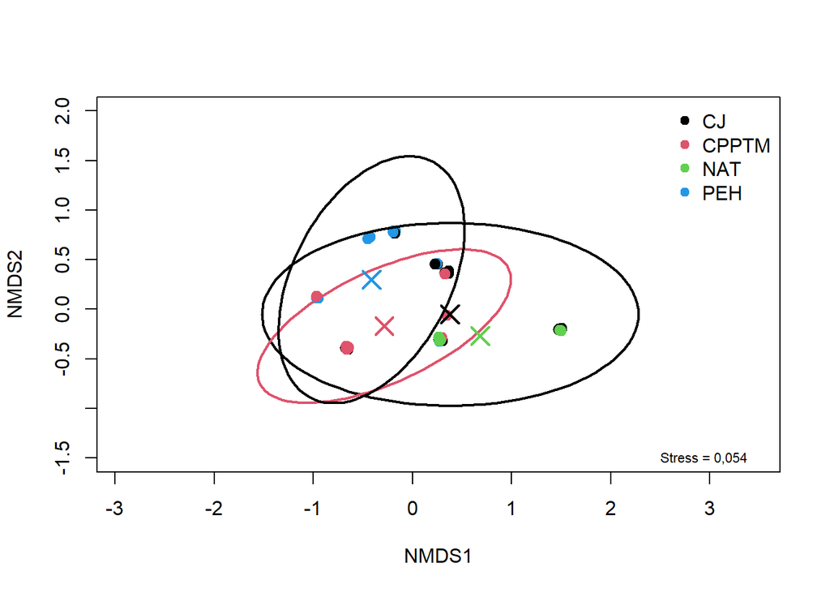

   ```r
   plot(nmds2, type = "n", ylim=c(-1.5,2))
   points(sc_jit,
          col = df2$Traitement,
          pch = 19,
          cex = 1.2)
   ordiellipse(nmds2,
     groups = df2$Traitement,
     show.groups = c("CJ", "CPPTM", "PEH"),
     kind = "sd",
     conf = 0.95,  draw = "line", col = c(1,2,4),
     lwd = 2)
   legend("topright",
     legend = levels(df2$Traitement),
     col = 1:length(levels(df2$Traitement)),
     pch = 19,
     bty = "n")
   points(cent$NMDS1, cent$NMDS2,
          pch = 4, cex = 2, lwd = 2,
          col = 1:length(levels(df2$Traitement)))
   text(x = 3.5,
        y = -1.5,
        labels = "Stress = 0,054",
        pos = 2, cex = 0.7)
   ```

   | n NAT = 6 n CJ = 19 | n CPPTM = 15 n PEH = 17 |
   | --- | --- |

   Ici, je n’ai pas fait apparaître l’ellipse de NAT puisqu’elle était représentée que par une ligne. Ceci est dut par la faible diversité des communautés d’amphibiens. Ainsi, NAT n’est représenté que par des points.
7. **Conclusion :**

   Les communautés d’amphibiens varies tous selon les types de traitements sauf les communautés qui se trouvent dans les étangs de CJ et NAT. Ainsi les communautés d’amphibiens dans les CJ sont similaire au milieux naturel utilisé en référence. Il semblerait alors que les communautés dans les plantations de PEH dans DOMTAR ne reflèterait pas le milieu naturel.

## Comment est-ce que les valeurs environnementales expliquent la composition en espèces d’amphibiens ?

Avec cela, voici l’analyse que j’ai fait :

1. **Préparation de la base de donnée :**

   ```r
   library(readxl)
   df2 <-read_excel("C:/Users/super/Université du Québec en Outaouais/CLAUDIE ÉTANGS VERNAUX - Documents/Stats/Structure_des_communautes/Data_Base_presenceV7.xlsx", sheet = 1)
   df2$Traitement <- as.factor(df2$Traitement)
   df2$Ph_moy <- as.numeric(df2$Ph_moy)
   df2$Temp_moy <- as.numeric(df2$Temp_moy)
   df2$superficie <- as.numeric(df2$superficie)
   df2$volume <- as.numeric(df2$volume)
   df2$Ouverture <- as.numeric(df2$Ouverture)
   df2$X <- as.numeric(df2$X)
   df2$Y <- as.numeric(df2$Y)
   df2[, 2:5] <- lapply(df2[, 2:5], as.numeric)
   df2$Debris_in<- as.numeric(factor(df2$Debris_in,levels = c("abscence", "faible", "eleve"),ordered = TRUE))
   df2$Debris_out<- as.numeric(factor(df2$Debris_out,levels = c("abscence", "faible", "eleve"),ordered = TRUE))
   #pour débris, voici les codes: 1=abscence, 2=faible, 3=moyen, 4=eleve)
   df2$Hydro<- factor(df2$Hydro, levels = c("hum", "sec"))
   df2
   ```

   ```
   # A tibble: 57 × 17
      No_etang   ambystoma  LICL  LISY  PSCR Traitement Ph_moy Temp_moy superficie
      <chr>          <dbl> <dbl> <dbl> <dbl> <fct>       <dbl>    <dbl>      <dbl>
    1 1WATCJ6            0     0     1     0 CJ           6.64     15.0    165000
    2 2WATCJ5            1     0     1     0 CJ           6.58     16.6    434700
    3 3WATCJ1            1     0     0     0 CJ           6.44     12.0     26600
    4 4WATCJ2            1     0     0     0 CJ           6.62     17.7    380800
    5 5WATCJ4            1     0     1     0 CJ           6.38     18.6     72000
    6 6WATCJ3            1     0     1     1 CJ           6.26     18.5    240000
    7 17WATPEH10         0     0     1     0 PEH          6.49     22.2     62059.
    8 7WATPEH2           0     0     1     1 PEH          6.33     15.6    267285.
    9 12WATPEH5          0     0     1     1 PEH          6.32     17.5    574453.
   10 8WATPEH1           0     0     1     1 PEH          6.49     13.9    133706.
   # ℹ 47 more rows
   # ℹ 8 more variables: volume <dbl>, Ouverture <dbl>, Debris_in <dbl>,
   #   Debris_out <dbl>, Hydro <fct>, Paires <dbl>, X <dbl>, Y <dbl>
   ```

   ```r
   #Je vais créer des objets pour faciliter les prochaines étapes.

   sp2=df2[, 2:5]
   trait2=df2$Traitement

   env <- df2[, c("Ph_moy", "Temp_moy", "superficie", "volume","Ouverture", "Debris_in", "Debris_out","Hydro")]
   env
   ```

   ```
   # A tibble: 57 × 8
      Ph_moy Temp_moy superficie volume Ouverture Debris_in Debris_out Hydro
       <dbl>    <dbl>      <dbl>  <dbl>     <dbl>     <dbl>      <dbl> <fct>
    1   6.64     15.0    165000   3878.     17.2          2          2 hum
    2   6.58     16.6    434700   5216.      5.2          1          2 hum
    3   6.44     12.0     26600    466.     26            1          2 sec
    4   6.62     17.7    380800  11805.      1.04         2          2 sec
    5   6.38     18.6     72000   1548       4.68         1          2 hum
    6   6.26     18.5    240000   5040       8.58         1          2 sec
    7   6.49     22.2     62059.   993.     51.0          1          1 hum
    8   6.33     15.6    267285.  8019.     72.8          1          1 hum
    9   6.32     17.5    574453. 11489.     78.3          1          2 hum
   10   6.49     13.9    133706.  4011.     44.7          1          1 hum
   # ℹ 47 more rows
   ```

   ```r
   Temperature <- env$Temp_moy
   pH <- env$Ph_moy
   Superficie <- env$superficie
   Volume <- env$volume
   Pourcentage_Ouverture <- env$Ouverture
   Presence_debris_hors_etang <- env$Debris_out
   Presence_debris_dans_etang <- env$Debris_in
   Hydro_ <- env$Hydro
   ```

2. **CCA ou RDA ? :**

   Pour savoir quel type d’analyse est la meilleure pour mes données, faut faire un test DCA

   ```r
   decorana(sp2)
   ```

   ```
   Call:
   decorana(veg = sp2)

   Detrended correspondence analysis with 26 segments.
   Rescaling of axes with 4 iterations.
   Total inertia (scaled Chi-square): 0.9308

                          DCA1   DCA2   DCA3    DCA4
   Eigenvalues          0.4044 0.2874 0.2930 0.28819
   Additive Eigenvalues 0.4044 0.2752 0.2512 0.00000
   Decorana values      0.4109 0.1354 0.0241 0.01099
   Axis lengths         2.2990 1.5051 1.6310 1.81649
   ```

   ```r
   sp3=decostand(sp2, method = "hellinger")
   ```

3. **Choix du modèle :**

   Premièrement, faut voir s’il y a de la collinéarité

   ```r
   modrda1 <- rda(sp3 ~ pH + Temperature + Superficie + Volume + Pourcentage_Ouverture + Presence_debris_dans_etang + Presence_debris_hors_etang+Hydro_+Condition(df2$X+df2$Y))
   vif.cca(modrda1)
   ```

   ```
                        df2$X                      df2$Y
                    10.776756                  12.139426
                           pH                Temperature
                     1.248862                   1.958111
                   Superficie                     Volume
                     2.856443                   2.960162
        Pourcentage_Ouverture Presence_debris_dans_etang
                     2.028167                   2.165212
   Presence_debris_hors_etang                  Hydro_sec
                     2.256228                   1.579914
   ```

   Tout est sous 3 donc tout va bien (sauf X er Y mais puisque c’est des conditions, on a pas besoin de les regarder), pas de collinéarité.

   J’ai essayé plusieurs méthodes pour trouver un bon modèle, mais le meilleur (R2 élevé en plus d’être parcimonieux) est ressorti avec ordistep()

   ```r
   modrda_null <- rda(sp3 ~ 1, data = env)
   select1 <- ordistep(modrda_null,scope = formula(modrda1),direction = "both",permutations = 999, trace = 0)
   select1
   ```

   ```
   Call: rda(formula = sp3 ~ Pourcentage_Ouverture + Hydro_ +
   Presence_debris_dans_etang + Condition(df2$X + df2$Y), data = env)

                 Inertia Proportion Rank
   Total         0.38021    1.00000
   Conditional   0.03127    0.08225    2
   Constrained   0.10096    0.26554    3
   Unconstrained 0.24797    0.65221    4

   Inertia is variance

   Eigenvalues for constrained axes:
      RDA1    RDA2    RDA3
   0.07555 0.02280 0.00262

   Eigenvalues for unconstrained axes:
       PC1     PC2     PC3     PC4
   0.12719 0.06157 0.04660 0.01260
   ```

   ```r
   #Les valeurs les plus importantes sont : Pourcentage d'ouverture, Hydrologie et Présence de débris hors de l'étang

   modrda6 <- rda(sp3 ~ Pourcentage_Ouverture +Hydro_+ Presence_debris_hors_etang+Condition(df2$X+df2$Y))
   RsquareAdj(modrda6)
   ```

   ```
   $r.squared
   [1] 0.260473

   $adj.r.squared
   [1] 0.2300247
   ```

   L’analyse de Moran effectué préalablement a relevé une autocorrélation. Afin de s’assurer que la prise en concidération de l’effet de la location des étangs sur la communauté, l’argument ‘’Condition(X + Y)’’ a été ajouté au modèle. Toutefois, cette méthode est rudimentaire comparé à d’autres approches plus complexe comme l’utilisation de MEM. Ainsi, une analyse de Particion de Variance sera effectué pour voir la proportion de la variation qui est expliqué par la position spatiale:

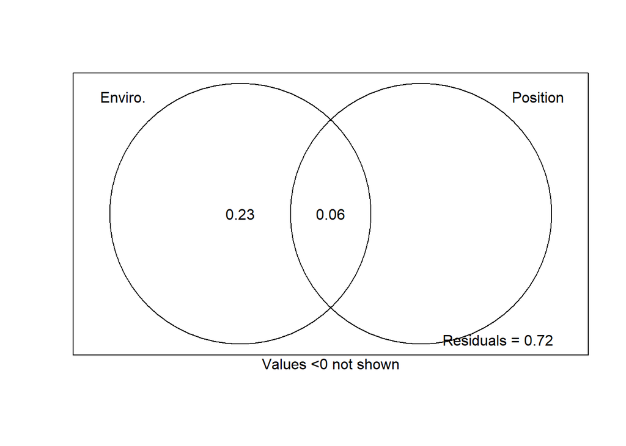

   ```r
   comm <- sp3

   env <- data.frame(Ouverture = df2$Ouverture, Hydro = df2$Hydro, Debris_out = df2$Debris_out)

   espace <-  data.frame(X = df2$X,Y = df2$Y)

   vp <- varpart(comm, env, espace)
   plot(vp, Xnames = c("Enviro.", "Position"), id.size=1)
   ```

   Avec ce graphique, il est possible de voir que l’environnement explique 23% de la variation et la position explique une portion négligeable de la variation. Ainsi, l’utilisation de l’argument ‘’Condition(X + Y)’’ semblerait approprié pour concidérer l’autocorrelation sans devoir s’embarquer dans l’inclusion de MEM dans le modèle.
5. **Visualisation :**

   Tout comme la PERMANOVA, il est préférable de voir les centroïdes. Ainsi, voici comment je les aient extraient

   ```r
   scores3 <- scores(modrda6, display = "sites")
   cent3 <- aggregate(scores3, by = list(trait = trait2), FUN = mean)
   ```

   Plusieurs points se superposent. Du jitter est donc préférable pour mieux interpréter le graphique

   ```r
   set.seed(123)
   scores3_jit <- scores3
   scores3_jit[,1] <- jitter(scores3[,1], amount = 0.03)
   scores3_jit[,2] <- jitter(scores3[,2], amount = 0.03)
   ```

   Pour bien comprendre il faut d’abord voir quel valeur affecte le plus les axes du graphique:

   ```r
   scores(modrda6, display = "bp")
   ```

   ```
                                    RDA1       RDA2
   Pourcentage_Ouverture       0.7113523 -0.4261351
   Hydro_sec                  -0.6973968 -0.1252507
   Presence_debris_hors_etang -0.3337798 -0.9146001
   attr(,"const")
   [1] 2.148086
   ```

   Ici on voit que l’axe 1 (x) est le plus influencé par l’ouverture et l’hydrologie. L’hydro sec est négatif, donc celui-ci se trouve au coté négatif du graph. L’axe 2 (y) est le plus influencé par la présence de débris autour de l’étang:

[figure not shown]

   Enfin, voici le graphique:

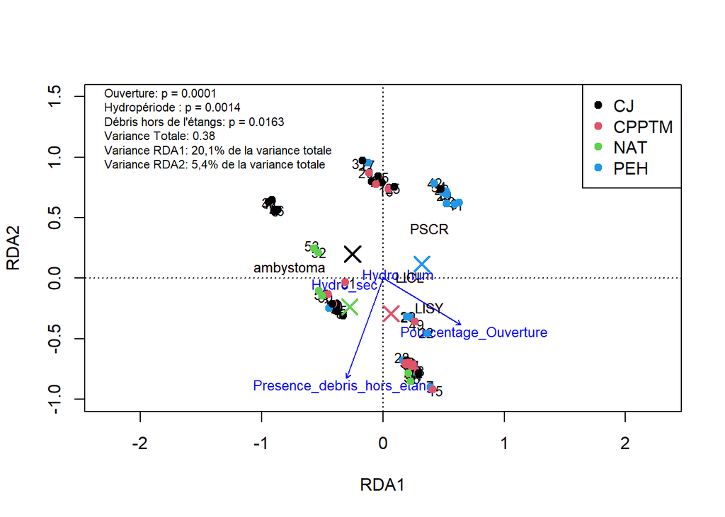

   ```r
   plot(modrda6, xlim = c(-1.5, 1.5), ylim = c(-1, 1.5), cex=0.8)
   points(scores3_jit[,1],scores3_jit[,2], display = 'sites' , col = as.numeric(trait2), pch=19)
   points(cent3$RDA1, cent3$RDA2, pch = 4, cex = 2, lwd = 2, col = 1:length(levels(trait2)))
   text(modrda6, display = "species", cex=0.8 )
   legend("topright", legend = levels(trait2), col = 1:length(levels(trait2)), pch = 19)
   text(x = -2.3, y = 1.30,
        labels = "RDA globale: p = 0,0001 \nOuverture: p = 0.0001 \nHydropériode : p = 0.0014 \nDébris hors de l'étangs: p = 0.0163 \nVariance Totale: 0.38 \nVariance RDA1: 20,1% de la variance totale \nVariance RDA2: 5,4% de la variance totale",
        adj = 0, cex = 0.69)
   ```

| n NAT = 6 n CJ = 19 | n CPPTM = 15 n PEH = 17 |
| --- | --- |

5. **Conclusion :**

   ```r
   modrda9 <- rda(sp3~ Pourcentage_Ouverture+ Hydro_+Condition(df2$X+df2$Y))
   RsquareAdj(modrda9)
   ```

   ```
   $r.squared
   [1] 0.2115651

   $adj.r.squared
   [1] 0.1912339
   ```

   Reste que, à elles seules, ces valeurs expliquent 19,12% de la variation des communautés.

   Avec la RDA, il semblerait que les ambystomes soit plutôt associées aux caractéristiques classiques d’un étang vernal (canopée fermée avec courte hydropériode). Ces caractéristiques sembleraient associés aux traitements NAT et CJ. Les LISY semblent beaucoup plus résistants à l’ouverture de la cannopée que les ambystomes. Ceci pourrait être expliqué par leur capacité de déplacement plus développées. Les grenouilles vertes (LICL) semblent associées avec les plantations.

   À noter que les ambystomes sont seules dans leur coin, celles-ci pourraient donc être à la source de la variation des populations entre les différents types de traitements puisque ce genre est celui qui diffère le plus des autres espèces d’amphibiens qui sont relativement proches les un des autres.

## Exploration des variables environnementales

### Ouverture de la cannopée:

1. **Préparation de la base de donnée :**

   ```r
   df <-read_excel("C:/Users/super/Université du Québec en Outaouais/CLAUDIE ÉTANGS VERNAUX - Documents/Stats/Structure_des_communautes/Data_Base_presenceV7.xlsx", sheet = 1)
   df2 <- df2[, c(1, 6, 11,17,16)]
   df2$Traitement <- as.factor(df2$Traitement)
   df2$No_etang <- as.factor(df2$No_etang)
   df2$X <- as.numeric(df2$X)
   df2$Y <- as.numeric(df2$Y)
   df2
   ```

   ```
   # A tibble: 57 × 5
      No_etang   Traitement Ouverture       Y      X
      <fct>      <fct>          <dbl>   <dbl>  <dbl>
    1 1WATCJ6    CJ             17.2  5054551 208574
    2 2WATCJ5    CJ              5.2  5054466 208550
    3 3WATCJ1    CJ             26    5051666 205768
    4 4WATCJ2    CJ              1.04 5051528 205599
    5 5WATCJ4    CJ              4.68 5051479 206257
    6 6WATCJ3    CJ              8.58 5051446 206212
    7 17WATPEH10 PEH            51.0  5048821 204369
    8 7WATPEH2   PEH            72.8  5048766 196250
    9 12WATPEH5  PEH            78.3  5046138 200919
   10 8WATPEH1   PEH            44.7  5048413 195920
   # ℹ 47 more rows
   ```

2. **Choix de l’analyse :**

   On commence en vérifiant la normalité des résidus:

   ```r
   mod <- lm(df2$Ouverture ~ df2$Traitement)
   shapiro.test(residuals(mod))
   ```

   ```
       Shapiro-Wilk normality test

   data:  residuals(mod)
   W = 0.92081, p-value = 0.001148
   ```

   Les résidus ne sont pas normaux et nous voulons aussi ajouter les locations X et Y en tant que effet fixe. Ainsi, on ne peux pas faire une ANOVA ni une Kruskal–Wallis. Puisque mes données sont en pourcentage entre 0 et 100, une régression beta serait intéressant. Elle ne requiert pas la normalité des résidus et permet d’inclure les valeurs X et Y.
3. **Régression Beta :**

   ```r
   df2$Ouverture_beta <- df2$Ouverture / 100
   df2$Ouverture_beta[df2$Ouverture_beta == 1] <- 0.999
   ```

   Avec cela, il est possible de créer le modèle:

   ```r
   library(betareg)
   beta <- betareg(df2$Ouverture_beta ~ df2$X + df2$Y + df2$Traitement)
   ```

   Juste pour s’assurer que le modèle est bon, il est préférable de le tester:

   ```r
   res <- residuals(beta, type = "quantile")
   shapiro.test(res)
   ```

   ```
       Shapiro-Wilk normality test

   data:  res
   W = 0.97625, p-value = 0.3225
   ```

   Les résiduts semblent être bon!

   ```r
   summary(beta)
   ```

   ```
   Call:
   betareg(formula = df2$Ouverture_beta ~ df2$X + df2$Y + df2$Traitement)

   Quantile residuals:
       Min      1Q  Median      3Q     Max
   -2.0726 -0.7487 -0.0478  0.6441  1.8373

   Coefficients (mean model with logit link):
                         Estimate Std. Error z value Pr(>|z|)
   (Intercept)          3.629e+00  1.242e+02   0.029   0.9767
   df2$X                1.790e-06  1.018e-05   0.176   0.8604
   df2$Y               -9.901e-07  2.498e-05  -0.040   0.9684
   df2$TraitementCPPTM  3.127e+00  3.904e-01   8.011 1.13e-15 ***
   df2$TraitementNAT   -1.004e+00  5.754e-01  -1.745   0.0811 .
   df2$TraitementPEH    2.622e+00  3.671e-01   7.143 9.15e-13 ***

   Phi coefficients (precision model with identity link):
         Estimate Std. Error z value Pr(>|z|)
   (phi)   3.5963     0.6998   5.139 2.76e-07 ***
   ---
   Signif. codes:  0 '***' 0.001 '**' 0.01 '*' 0.05 '.' 0.1 ' ' 1

   Type of estimator: ML (maximum likelihood)
   Log-likelihood: 56.67 on 7 Df
   Pseudo R-squared: 0.5949
   Number of iterations: 99 (BFGS) + 15 (Fisher scoring)
   ```

   C’est significatif! Au moins un traitement a une ouverture de la canopée qui diffère des autres.
4. **Post-hoc : Emmeans**

   ```r
   library(emmeans)
   posthoc <- emmeans(beta,~ Traitement,type = "response")
   pairs(posthoc, adjust = "holm")
   ```

   ```
    contrast    estimate     SE  df z.ratio p.value
    CJ - CPPTM    -0.618 0.0551 Inf -11.220 <0.0001
    CJ - NAT       0.155 0.0736 Inf   2.111  0.0695
    CJ - PEH      -0.562 0.0605 Inf  -9.301 <0.0001
    CPPTM - NAT    0.774 0.0689 Inf  11.228 <0.0001
    CPPTM - PEH    0.056 0.0407 Inf   1.376  0.1689
    NAT - PEH     -0.718 0.0730 Inf  -9.833 <0.0001

   P value adjustment: holm method for 6 tests
   ```

   Ici, ils diffèrent tous sauf CPPTM-PEH et CJ-NAT qui se ressemblent au niveau de l’ouverture de la cannopée.
5. **Visualisation :**

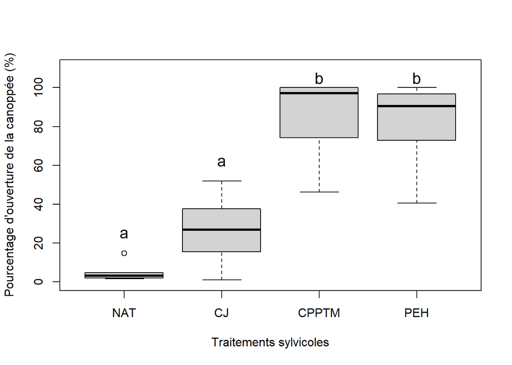

   ```r
   par(mfrow = c(1,1))
   df2$Traitement <- factor(df2$Traitement, levels = c("NAT", "CJ", "CPPTM", "PEH"))

   boxplot(df2$Ouverture ~ df2$Traitement,ylab = "Pourcentage d'ouverture de la canoppée (%)", xlab = "Traitements sylvicoles",ylim=c(0,110))
   text(x = 1, y = 25, labels = "a", cex = 1.3)   # NAT
   text(x = 2, y = 62, labels = "a", cex = 1.3)  # CJ
   text(x = 3, y = 105, labels = "b", cex = 1.3)   # CPPTM
   text(x = 4, y = 105, labels = "b", cex = 1.3)  # PEH
   ```

| n NAT = 6 n CJ = 19 | n CPPTM = 15 n PEH = 17 |
| --- | --- |

6. **Conclusion :**

   Le pourcentage de l’ouverture de la canopée des CJ est similaire à celle dans les références en milieu naturel. L’ouverture de la canopée dans les plantations n’est pas du tout similaire à celle du milieu naturel et ressemble plutôt à celle des traitements CPPTM qui coupe presque la majorité de la canopée. Ceci pourrait expliquer pourquoi les ambystomes ne sont presque pas présentes dans les plantations.

### Hydrologie :

1. **Préparation des données :**

   ```r
   df3 <-read_excel("C:/Users/super/Université du Québec en Outaouais/CLAUDIE ÉTANGS VERNAUX - Documents/Stats/Structure_des_communautes/Data_Base_presenceV7.xlsx", sheet = 1)
   df4 <- df3[, c(1, 6, 14,17,16)]
   df4$Traitement <- as.factor(df4$Traitement)
   df4$No_etang <- as.factor(df4$No_etang)
   df4$Hydro <- factor(df4$Hydro, levels = c("sec", "hum"))
   df4$X <- as.numeric(df4$X)
   df4$Y <- as.numeric(df4$Y)
   df4
   ```

   ```
   # A tibble: 57 × 5
      No_etang   Traitement Hydro       Y      X
      <fct>      <fct>      <fct>   <dbl>  <dbl>
    1 1WATCJ6    CJ         hum   5054551 208574
    2 2WATCJ5    CJ         hum   5054466 208550
    3 3WATCJ1    CJ         sec   5051666 205768
    4 4WATCJ2    CJ         sec   5051528 205599
    5 5WATCJ4    CJ         hum   5051479 206257
    6 6WATCJ3    CJ         sec   5051446 206212
    7 17WATPEH10 PEH        hum   5048821 204369
    8 7WATPEH2   PEH        hum   5048766 196250
    9 12WATPEH5  PEH        hum   5046138 200919
   10 8WATPEH1   PEH        hum   5048413 195920
   # ℹ 47 more rows
   ```

2. **Choix de l’analyse :**

   Cette base de donnée est binaire ‘’sec’’ ou ‘’humide’’ et les valeurs spatiales doivent être pris en compte. Un modèle de la famille binomial serait intéressant.

   ```r
   table(df4$Traitement, df4$Hydro)
   ```

   ```
           sec hum
     CJ      8  11
     CPPTM   4  11
     NAT     4   2
     PEH     0  17
   ```

   De plus, il semble y avoir une séparation complète puisque PEH a zéro sec!

   ```r
   library(detectseparation)
   sep <- glm(Hydro ~ Traitement + X + Y, data = df4,family = binomial,method = "detect_separation")
   sep
   ```

   ```
   Implementation: ROI | Solver: lpsolve
   Separation: TRUE
   Existence of maximum likelihood estimates
       (Intercept) TraitementCPPTM   TraitementNAT   TraitementPEH               X
                 0               0               0             Inf               0
                 Y
                 0
   0: finite value, Inf: infinity, -Inf: -infinity
   ```

   Cette analyse confirme la séparation et indique aussi qu’elle est causée par PEH. Ceci signifie qu’un GLM binomial sans correction pourrait s’avérer moins fiable. Ainsi, pour cette analyse, deux modèles sera comparés: un modèle avec et sans correction (la correction ici sera brglmFit)
3. **GLM binomial**

   ```r
   #SANS brglmFit
   mod2 <- glm(Hydro ~ Traitement + X + Y,data=df4,family=binomial)

   #AVEC brglmFit
   library(brglm2)
   mod2_2 <- glm(Hydro ~ Traitement + X+ Y,data=df4,family=binomial,method="brglmFit")
   ```

   Avant de continuer, il faut s’assurer que les modèles sont bons.

   ```r
   #SANS brglmFit
   library(DHARMa)
   mod2$converged
   ```

   ```
   [1] TRUE
   ```

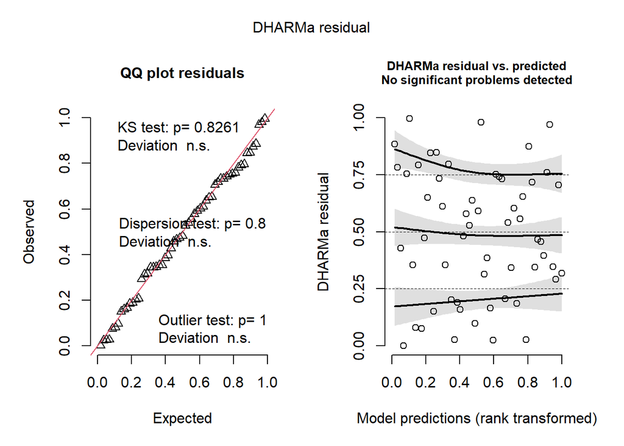

   ```r
   res <- simulateResiduals(mod2, n=1000)
   plot(res)
   ```

   ```r
   #AVEC brglmFit
   mod2_2$converged
   ```

   ```
   [1] TRUE
   ```

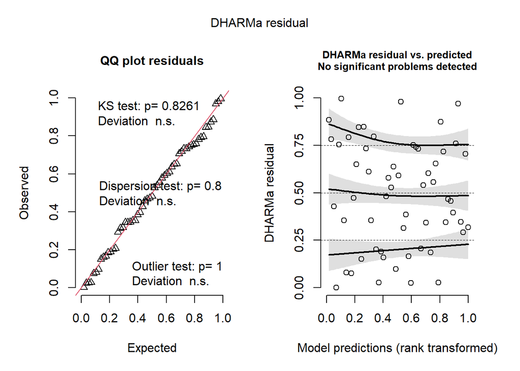

   ```r
   res <- simulateResiduals(mod2, n=1000)
   plot(res)
   ```

   Les deux modèles ont des résultats qui semblent bien se tenir. On peut maintenant passer à l’analyse

   ```r
   #SANS brglmfit
   anova(mod2, test="Chisq")
   ```

   ```
   Analysis of Deviance Table

   Model: binomial, link: logit

   Response: Hydro

   Terms added sequentially (first to last)

              Df Deviance Resid. Df Resid. Dev  Pr(>Chi)
   NULL                          56     67.672
   Traitement  3  16.7725        53     50.900 0.0007871 ***
   X           1   0.0286        52     50.871 0.8655927
   Y           1   4.9886        51     45.882 0.0255148 *
   ---
   Signif. codes:  0 '***' 0.001 '**' 0.01 '*' 0.05 '.' 0.1 ' ' 1
   ```

   ```r
   #AVEC brglmfit
   anova(mod2_2, test="Chisq")
   ```

   ```
   Analysis of Deviance Table

   Model: binomial, link: logit

   Response: Hydro

   Terms added sequentially (first to last)

              Df Deviance Resid. Df Resid. Dev Pr(>Chi)
   NULL                          56     67.676
   Traitement  3   15.787        53     51.889 0.001254 **
   X           1    0.000        52     51.939 1.000000
   Y           1    4.571        51     47.368 0.032518 *
   ---
   Signif. codes:  0 '***' 0.001 '**' 0.01 '*' 0.05 '.' 0.1 ' ' 1
   ```

   Pour les deux modèles, Traitement est significatif. Au moins un traitement diffère des autres.
4. **Post-hoc : Emmeans**

   ```r
   #SANS brglmfit
   pairs(emmeans(mod2, ~Traitement, type="response"), adjust="tukey")
   ```

   ```
    contrast    odds.ratio       SE  df null z.ratio p.value
    CJ / CPPTM       0.612 4.72e-01 Inf    1  -0.637  0.9200
    CJ / NAT         0.845 1.22e+00 Inf    1  -0.116  0.9994
    CJ / PEH         0.000 1.38e-05 Inf    1  -0.007  1.0000
    CPPTM / NAT      1.380 2.10e+00 Inf    1   0.212  0.9966
    CPPTM / PEH      0.000 2.26e-05 Inf    1  -0.007  1.0000
    NAT / PEH        0.000 1.63e-05 Inf    1  -0.007  1.0000

   P value adjustment: tukey method for comparing a family of 4 estimates
   Tests are performed on the log odds ratio scale
   ```

   ```r
   #AVEC brglmfit
   pairs(emmeans(mod2_2, ~Traitement, type="response"), adjust="tukey")
   ```

   ```
    contrast    odds.ratio     SE  df null z.ratio p.value
    CJ / CPPTM      0.6191 0.4640 Inf    1  -0.640  0.9191
    CJ / NAT        0.9163 1.1900 Inf    1  -0.067  0.9999
    CJ / PEH        0.0481 0.0723 Inf    1  -2.018  0.1811
    CPPTM / NAT     1.4802 2.0500 Inf    1   0.284  0.9921
    CPPTM / PEH     0.0777 0.1200 Inf    1  -1.657  0.3465
    NAT / PEH       0.0525 0.0977 Inf    1  -1.584  0.3880

   P value adjustment: tukey method for comparing a family of 4 estimates
   Tests are performed on the log odds ratio scale
   ```

   Les résultats du GLM avec la correction brglmFit semble plus fiables (les odds ratios qui n’atteignent pas zéro et des SE plus réalistes). Ainsi, l’interprétation devrait être faite avec ce modèle.  
   Surprenament, ici, aucune paire de traitement est significatif alors que l’analyse Chisq avait révélé qu’il semblerait y avoir une différence entre certains traitements. Ceci pourrait être causé par le manque de donnée, particulièrement pour NAT qui a un n de seulement 6. Ainsi, plus d’échantillonage serait nécessaire pour pousser cette analyse plus loin et déterminer quels traitements diffèrent les uns des autres.
5. **Visualisation :**

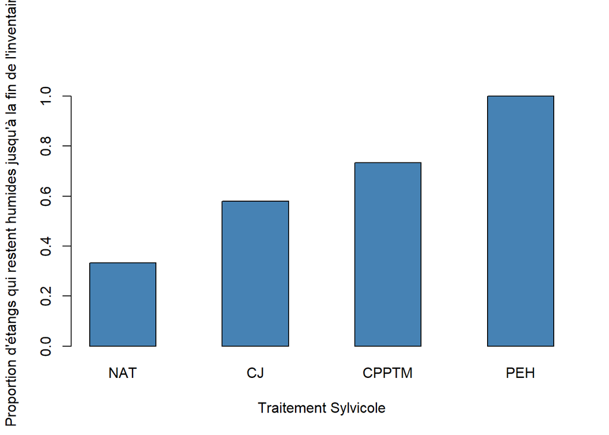

   ```r
   par(mfrow = c(1,1))
   df4$Traitement <- factor(df4$Traitement, levels = c("NAT", "CJ", "CPPTM", "PEH"))
   tab <- prop.table(table(df4$Traitement, df4$Hydro), margin = 1)[, "hum", drop = FALSE]

   barplot(t(tab),
           beside = TRUE,
           col = "steelblue",
           ylim = c(0, 1.1),
           ylab = "Proportion d'étangs qui restent humides jusqu'à la fin de l'inventaire",
           xlab = "Traitement Sylvicole")
   ```

| n NAT = 6 n CJ = 19 | n CPPTM = 15 n PEH = 17 |
| --- | --- |

Ici, il semble avoir un pattern malgré le manque de significativité ce qui est supporté par l’analyse Chisq significative. Plus le traitement sylvicole est intensif, plus les étangs restent humides longtemps.

7. **Conclusion** :

   Ici, il n’y a pas assez de données pour obtenir un résultat significatif. Toutefois, en regardant le graphique à barre, une tendance semble claire: Les étangs dans les plantations ne semble presque jamais sécher alors que ceux dans les NAT et CJ semble sécher beaucoup plus souvent. Ainsi, l’hydrologie des étangs dans les plantations ne semblent pas refléter ce qui est observé en nature. Toutefois, plus d’échantillonage serait nécessaire pour confirmer cette théorie.

1. **Préparation des données :**

   ```r
   df5 <-read_excel("C:/Users/super/Université du Québec en Outaouais/CLAUDIE ÉTANGS VERNAUX - Documents/Stats/Structure_des_communautes/Data_Base_presenceV7.xlsx", sheet = 1)
   df6 <- df5[, c(1, 6, 13,17,16)]
   df6$Traitement <- as.factor(df6$Traitement)
   df6$No_etang <- as.factor(df6$No_etang)
   df6$Debris_out<- factor(df6$Debris_out,levels = c("abscence","faible","eleve"),ordered = TRUE)
   df6$X_z <- as.numeric(scale(df6$X))
   df6$Y_z <- as.numeric(scale(df6$Y))
   df6
   ```

   ```
   # A tibble: 57 × 7
      No_etang   Traitement Debris_out       Y      X    X_z    Y_z
      <fct>      <fct>      <ord>        <dbl>  <dbl>  <dbl>  <dbl>
    1 1WATCJ6    CJ         faible     5054551 208574 -0.984 -0.704
    2 2WATCJ5    CJ         faible     5054466 208550 -0.984 -0.709
    3 3WATCJ1    CJ         faible     5051666 205768 -1.05  -0.864
    4 4WATCJ2    CJ         faible     5051528 205599 -1.06  -0.872
    5 5WATCJ4    CJ         faible     5051479 206257 -1.04  -0.875
    6 6WATCJ3    CJ         faible     5051446 206212 -1.04  -0.877
    7 17WATPEH10 PEH        abscence   5048821 204369 -1.09  -1.02
    8 7WATPEH2   PEH        abscence   5048766 196250 -1.28  -1.03
    9 12WATPEH5  PEH        faible     5046138 200919 -1.17  -1.17
   10 8WATPEH1   PEH        abscence   5048413 195920 -1.29  -1.05
   # ℹ 47 more rows
   ```

2. **Choix des analyses :**

   On recherche un test qui est capable de prendre en compte les niveaux de débris:  
   absence < faible < élevé  
   Une régression logistique ordianle (CLM) serait alors idéale. Par contre, il y a beaucoup de zéros dans la base de donnée:

   ```r
   table(df6$Traitement,df6$Debris_out)
   ```

   ```
           abscence faible eleve
     CJ           1     15     3
     CPPTM        1      2    12
     NAT          0      6     0
     PEH         10      5     2
   ```

   Il faut donc s’assurer que le modèle converge avant de continuer :

   ```r
   library(ordinal)
   mod3 <- clm(Debris_out ~ Traitement+X_z+Y_z, data = df6)
   summary(mod3)
   ```

   ```
   formula: Debris_out ~ Traitement + X_z + Y_z
   data:    df6

    link  threshold nobs logLik AIC   niter max.grad cond.H
    logit flexible  57   -42.09 98.18 6(0)  2.36e-11 5.1e+01

   Coefficients:
                   Estimate Std. Error z value Pr(>|z|)
   TraitementCPPTM   2.5896     0.8374   3.092  0.00199 **
   TraitementNAT     0.4032     1.1182   0.361  0.71839
   TraitementPEH    -2.4487     0.8137  -3.010  0.00262 **
   X_z              -1.2725     0.8608  -1.478  0.13933
   Y_z               1.2900     0.9046   1.426  0.15386
   ---
   Signif. codes:  0 '***' 0.001 '**' 0.01 '*' 0.05 '.' 0.1 ' ' 1

   Threshold coefficients:
                   Estimate Std. Error z value
   abscence|faible  -2.1260     0.6345  -3.351
   faible|eleve      1.3819     0.5264   2.625
   ```

   Tout indique que le modèle est acceptable, donc ce sera un CLM qui sera effectué.
3. **CLM :**

   ```r
   anova(mod3)
   ```

   ```
   Type I Analysis of Deviance Table with Wald chi-square tests

              Df   Chisq Pr(>Chisq)
   Traitement  3 23.4520   3.25e-05 ***
   X_z         1  0.2000     0.6547
   Y_z         1  2.0336     0.1539
   ---
   Signif. codes:  0 '***' 0.001 '**' 0.01 '*' 0.05 '.' 0.1 ' ' 1
   ```

   Le p-value est significatif, les niveaux de présence de débris diffère dans au moins un type de traitement sylvicole.
4. **Post-Hoc : Emmeans**

   ```r
   emm2 <-  emmeans(mod3, ~ Traitement)
   pairs(emm2, adjust = "holm")
   ```

   ```
    contrast    estimate    SE  df z.ratio p.value
    CJ - CPPTM    -2.590 0.837 Inf  -3.092  0.0099
    CJ - NAT      -0.403 1.120 Inf  -0.361  0.7184
    CJ - PEH       2.449 0.814 Inf   3.010  0.0105
    CPPTM - NAT    2.186 1.270 Inf   1.728  0.1681
    CPPTM - PEH    5.038 1.050 Inf   4.819 <0.0001
    NAT - PEH      2.852 1.250 Inf   2.290  0.0661

   P value adjustment: holm method for 6 tests
   ```

   Ici, il y a une différence significatif entre chaque traitements mais NAT ressemblerait à tout le monde.
5. **Visualisation :**

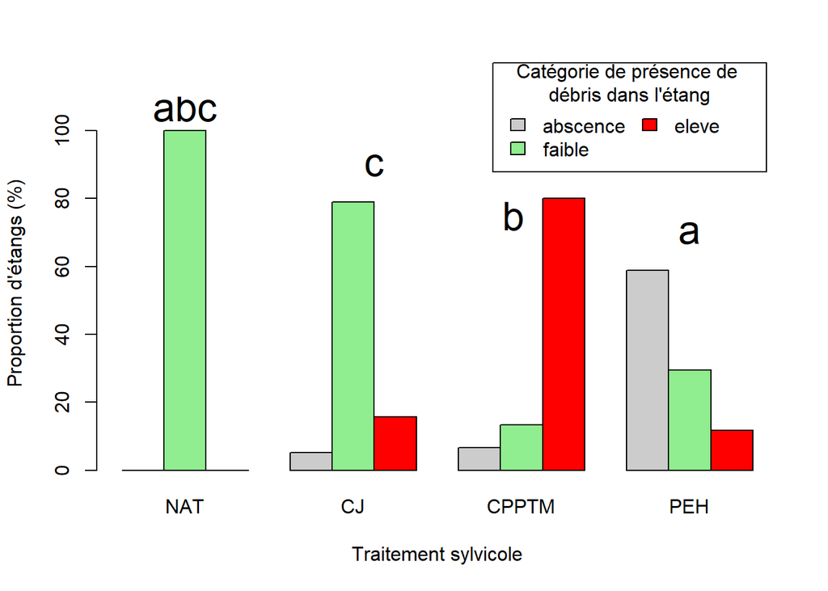

   ```r
   df6$Traitement <- factor(df6$Traitement, levels = c("NAT", "CJ", "CPPTM", "PEH"))
   tab1 <- table(df6$Traitement, df6$Debris_out)
   prop <- prop.table(tab1, margin = 1)* 100 #c'est plus intéressant si je montre les proportions
   cols <- c("grey80", "lightgreen", "red")

   barplot(t(prop), beside = TRUE, xlab = "Traitement sylvicole", ylab = "Proportion d'étangs (%)",ylim = c(0,110), names.arg = rownames(tab1), legend.text = colnames(tab1), col = cols, args.legend = list(title = "Catégorie de présence de \ndébris dans l'étang", y = 120,ncol=2))
   text(x = 2.5, y = 107, labels = "abc", cex = 2)   # NAT
   text(x = 7, y = 90, labels = "c", cex = 2)  # CJ
   text(x = 10.3, y = 75, labels = "b", cex = 2)   # CPPTM
   text(x = 14.5, y = 70, labels = "a", cex = 2)  # PEH
   ```

| n NAT = 6 n CJ = 19 | n CPPTM = 15 n PEH = 17 |
| --- | --- |

6. **Conclusion :**

   Ici, presque tous les traitements sylvicoles seraient significament différents les un des autres sauf NAT. Toutefois, ceci pourrait être causé par un manque d’échantillonage.

## Est-ce certaines espèces sont associés à certains traitements sylvicoles ? Pourquoi ?

Les types de traitements modifie l’habitat des amphibiens, notamment, l’ouverture de la canopée, la présence de débris dans les étant et, probablement (mais sans résultats définitifs), l’hydropériode. La RDA précédente semble avoir révélé que les ambystomes sont des espèces spécifiquement associées à un habitat différent que les autres amphibiens puisqu’elles sont isolée dans un coin près de NAT et CJ. Serait-elles des espèces indicatrices qui expliquerait la séparation significative de la communautée entre NAT/CJ et les autres types de traitements?

1.1 **Préparation des données:**

```r
df <-read_excel("C:/Users/super/Université du Québec en Outaouais/CLAUDIE ÉTANGS VERNAUX - Documents/Stats/Structure_des_communautes/Data_Base_presenceV7.xlsx", sheet = 1)
sp <- df[, c("ambystoma", "LISY", "LICL", "PSCR")]
sp
```

```
# A tibble: 57 × 4
   ambystoma  LISY  LICL  PSCR
       <dbl> <dbl> <dbl> <dbl>
 1         0     1     0     0
 2         1     1     0     0
 3         1     0     0     0
 4         1     0     0     0
 5         1     1     0     0
 6         1     1     0     1
 7         0     1     0     0
 8         0     1     0     1
 9         0     1     0     1
10         0     1     0     1
# ℹ 47 more rows
```

1.2 **Choix de l’analyse :**

Le code suivant révèle qu’aucune espèce est excessivement rare:

```r
colSums(sp)
```

```
ambystoma      LISY      LICL      PSCR
       28        50        10        18
```

Ainsi, il est possible de faire l’analyse IndVal (Indicator Species Analysis) pour répondre à la question.

1.3 **IndVal :**

```r
library(indicspecies)
res <- multipatt(sp,cluster = df$Traitement,func = "IndVal.g",control = how(nperm = 9999))
summary(res)
```

```
 Multilevel pattern analysis
 ---------------------------

 Association function: IndVal.g
 Significance level (alpha): 0.05

 Total number of species: 4
 Selected number of species: 1
 Number of species associated to 1 group: 0
 Number of species associated to 2 groups: 1
 Number of species associated to 3 groups: 0

 List of species associated to each combination:

 Group CJ+NAT  #sps.  1
           stat p.value
ambystoma 0.785   3e-04 ***
---
Signif. codes:  0 '***' 0.001 '**' 0.01 '*' 0.05 '.' 0.1 ' ' 1
```

**2.1 Pousser plus loin : Qu’est-ce qui explique la présence des ambystomes dans les NAT/CJ ?**

On sait que les traitements affecte l’habitat et on a découvert que les valeurs environnementales suivantes semblent celles qui détermine le plus les communautés d’amphibiens: L’ouverture de la canopée, l’hydropériode et la présence de débris dans les étangs. Mais, spécifiquement pour les ambystomes, qui ont maintenant été définie comme des espèces indicatrices de CJ/NAT, quel valeur environnementales influence le plus leur présence/absence dans l’habitat?

2.2 **Préparation des données :**

```r
df <-read_excel("C:/Users/super/Université du Québec en Outaouais/CLAUDIE ÉTANGS VERNAUX - Documents/Stats/Structure_des_communautes/Data_Base_presenceV7.xlsx", sheet = 1)
df$Traitement <- as.factor(df$Traitement)
df$Ouverture <- as.numeric(df$Ouverture)
df[, 2:5] <- lapply(df[, 2:5], as.numeric)
df$Debris_out<- as.numeric(factor(df$Debris_out,levels = c("abscence", "faible", "moyen", "eleve"),ordered = TRUE))
#pour débris, voici les codes: 1=abscence, 2=faible, 3=eleve)
df$Hydro<- factor(df$Hydro, levels = c("hum", "sec"))
df
```

```
# A tibble: 57 × 17
   No_etang   ambystoma  LICL  LISY  PSCR Traitement Ph_moy Temp_moy superficie
   <chr>          <dbl> <dbl> <dbl> <dbl> <fct>       <dbl>    <dbl>      <dbl>
 1 1WATCJ6            0     0     1     0 CJ           6.64     15.0    165000
 2 2WATCJ5            1     0     1     0 CJ           6.58     16.6    434700
 3 3WATCJ1            1     0     0     0 CJ           6.44     12.0     26600
 4 4WATCJ2            1     0     0     0 CJ           6.62     17.7    380800
 5 5WATCJ4            1     0     1     0 CJ           6.38     18.6     72000
 6 6WATCJ3            1     0     1     1 CJ           6.26     18.5    240000
 7 17WATPEH10         0     0     1     0 PEH          6.49     22.2     62059.
 8 7WATPEH2           0     0     1     1 PEH          6.33     15.6    267285.
 9 12WATPEH5          0     0     1     1 PEH          6.32     17.5    574453.
10 8WATPEH1           0     0     1     1 PEH          6.49     13.9    133706.
# ℹ 47 more rows
# ℹ 8 more variables: volume <dbl>, Ouverture <dbl>, Debris_in <chr>,
#   Debris_out <dbl>, Hydro <fct>, Paires <dbl>, X <dbl>, Y <dbl>
```

```r
Ouverture <- df$Ouverture
df$Debris_out <- ordered(df$Debris_out)
Debris_out <- df$Debris_out
Hydro <- df$Hydro
```

2.3 **Choix de l’analyse** :  
Pour pouvoir analyser l’impact de chaque valeur environnementales, il serait préférable de comparer des modèles de GLM entre eux. Pour se faire, je vais juste m’assurer qu’un modèle global respecte les conditions d’un GLM binomial:

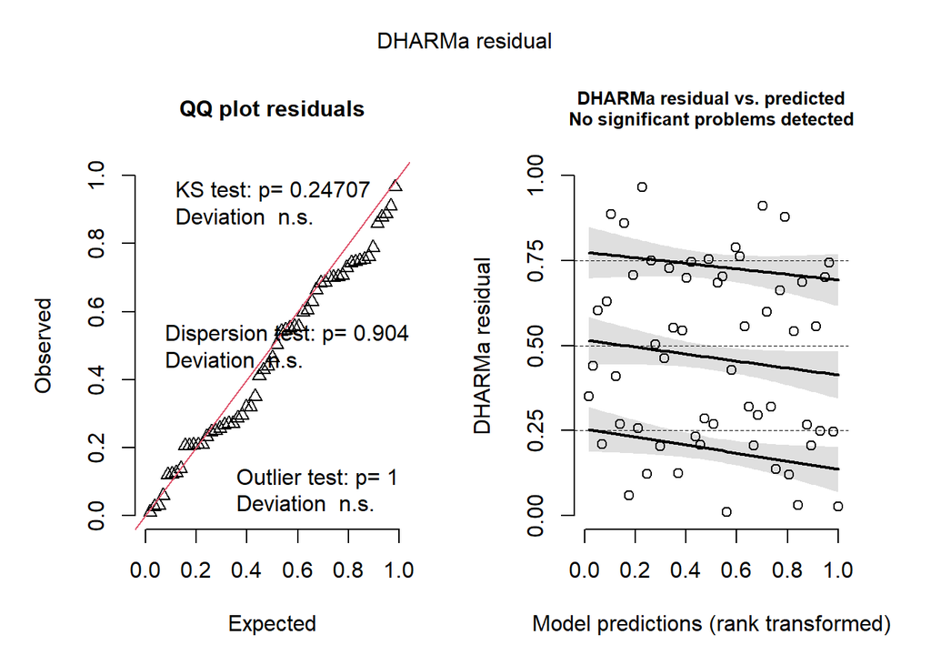

```r
library(car)
mod_test <- glm(ambystoma ~ Ouverture + Hydro + Debris_out +X +Y ,family = binomial, data=df)
res <- simulateResiduals(mod_test) #validation du modèle corrigé
plot(res)
```

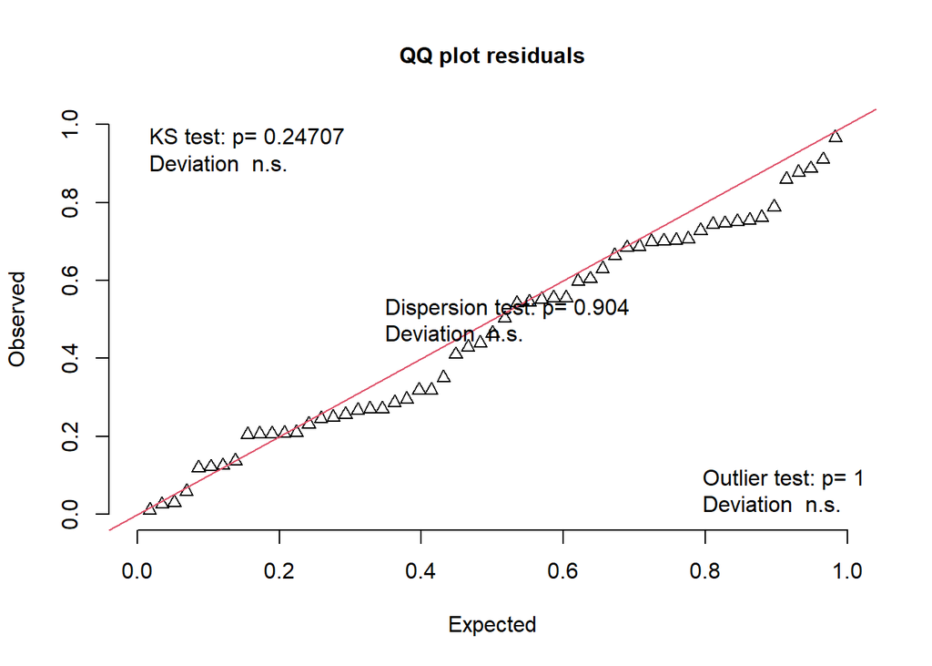

```
    Exact one-sample Kolmogorov-Smirnov test

data:  simulationOutput$scaledResiduals
D = 0.13248, p-value = 0.2471
alternative hypothesis: two-sided
```

```r
testUniformity(res) #uniformité des résidus (p-value plus de 0.05) Good!
```

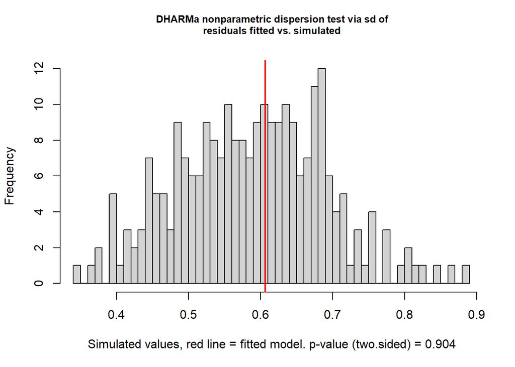

```
    DHARMa nonparametric dispersion test via sd of residuals fitted vs.
    simulated

data:  simulationOutput
dispersion = 1.0309, p-value = 0.904
alternative hypothesis: two.sided
```

```r
testDispersion(res) #Pas de surdispersion (p-value plus de 0.05) Good!
```

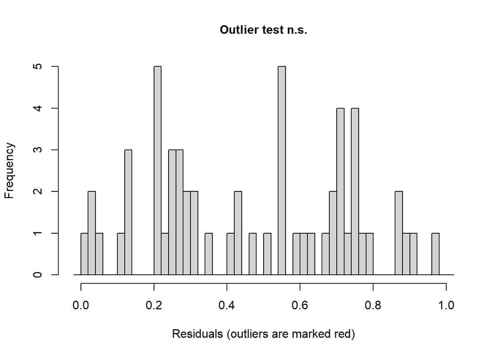

```
    DHARMa bootstrapped outlier test

data:  res
outliers at both margin(s) = 0, observations = 57, p-value = 1
alternative hypothesis: two.sided
 percent confidence interval:
 0 0
sample estimates:
outlier frequency (expected: 0.000175438596491228 )
                                                  0
```

```r
testOutliers(res) #0 Outliers, Good!
```

Ici, tout semble très beau, on peux continuer avec l’analyse

2.4 **Choix des valeurs : AICc**

Je vais créer différents types de modèles pour pouvoir les comparer les uns aux autres avec l’AICc. Les modèles seront aussi vérifiés pour s’assurer qu’ils sont fonctionnels

-Modèle Null

```r
mod0 <- glm(ambystoma ~ 1, family = binomial, data = df)
```

-Modèle avec juste l’ouverture de la canopée

```r
mod_can <- glm(ambystoma ~ Ouverture+X+Y,family = binomial,data = df)
summary(mod_can)
```

```
Call:
glm(formula = ambystoma ~ Ouverture + X + Y, family = binomial,
    data = df)

Coefficients:
              Estimate Std. Error z value Pr(>|z|)
(Intercept)  6.160e+02  4.703e+02   1.310 0.190273
Ouverture   -3.259e-02  9.900e-03  -3.292 0.000994 ***
X            5.020e-05  3.742e-05   1.341 0.179796
Y           -1.236e-04  9.459e-05  -1.307 0.191118
---
Signif. codes:  0 '***' 0.001 '**' 0.01 '*' 0.05 '.' 0.1 ' ' 1

(Dispersion parameter for binomial family taken to be 1)

    Null deviance: 79.001  on 56  degrees of freedom
Residual deviance: 58.650  on 53  degrees of freedom
AIC: 66.65

Number of Fisher Scoring iterations: 5
```

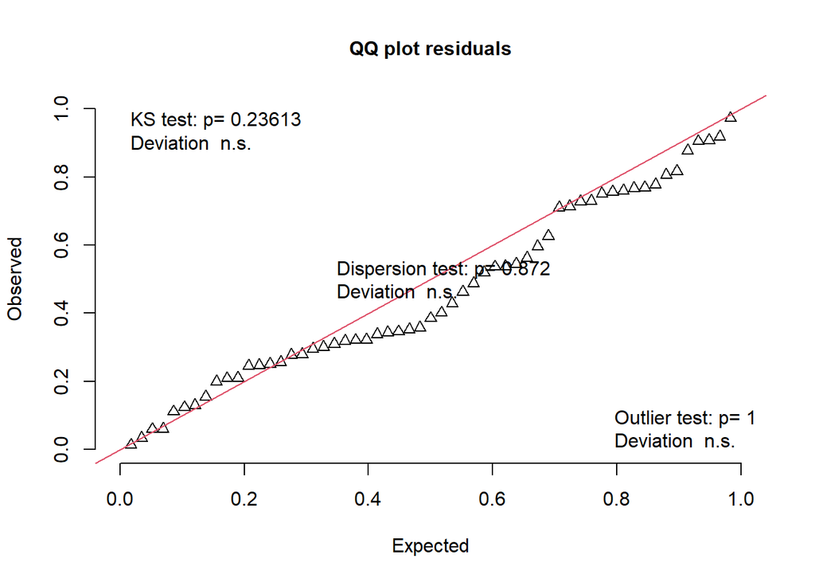

```
    Exact one-sample Kolmogorov-Smirnov test

data:  simulationOutput$scaledResiduals
D = 0.13394, p-value = 0.2361
alternative hypothesis: two-sided
```

```r
res2 <- simulateResiduals(mod_can)
testUniformity(res2) #uniformité des résidus (p-value plus de 0.05) Good!
```

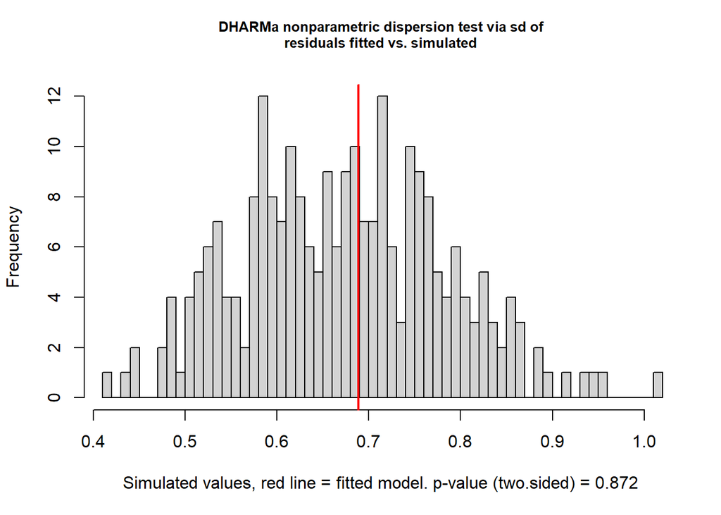

```
    DHARMa nonparametric dispersion test via sd of residuals fitted vs.
    simulated

data:  simulationOutput
dispersion = 1.0234, p-value = 0.872
alternative hypothesis: two.sided
```

```r
testDispersion(res2) #Pas de surdispersion (p-value plus de 0.05) Good!
```

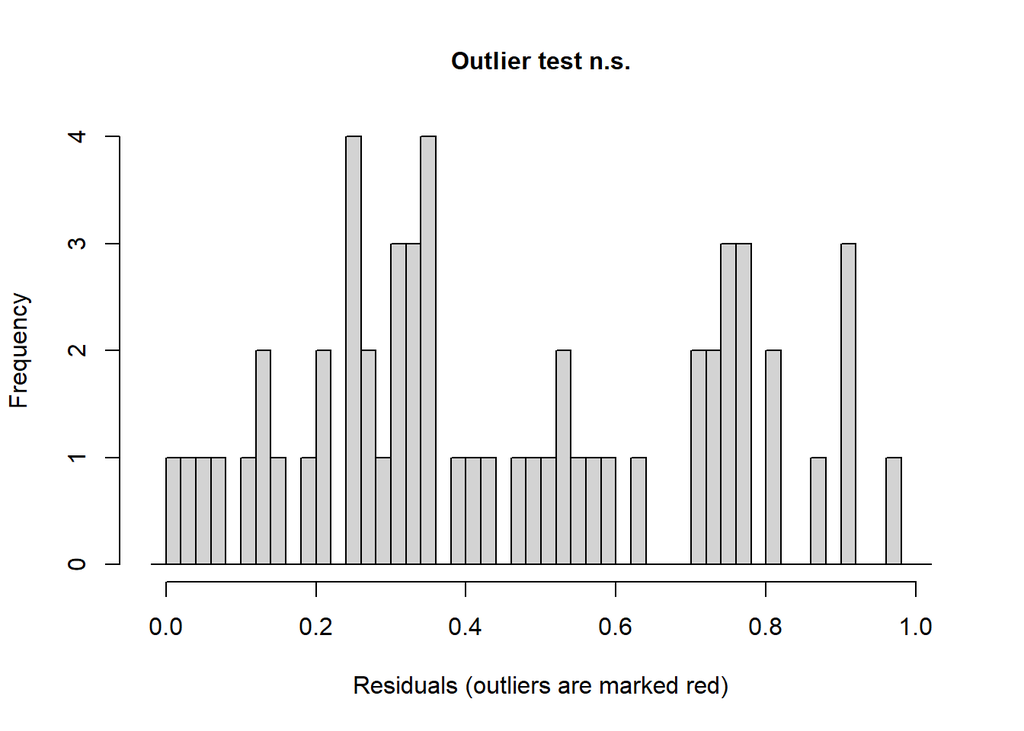

```
    DHARMa bootstrapped outlier test

data:  res2
outliers at both margin(s) = 0, observations = 57, p-value = 1
alternative hypothesis: two.sided
 percent confidence interval:
 0 0
sample estimates:
outlier frequency (expected: 0 )
                               0
```

```r
testOutliers(res2) #Zéro Outliers, good!
```

-Modèle avec juste l’hydropériode

```r
mod_hydro <- glm(ambystoma ~ Hydro+X+Y,family = binomial,data = df)
summary(mod_hydro)
```

```
Call:
glm(formula = ambystoma ~ Hydro + X + Y, family = binomial, data = df)

Coefficients:
              Estimate Std. Error z value Pr(>|z|)
(Intercept)  6.079e+02  4.277e+02   1.421   0.1553
Hydrosec     1.634e+00  7.522e-01   2.172   0.0298 *
X            4.646e-05  3.432e-05   1.354   0.1758
Y           -1.223e-04  8.603e-05  -1.422   0.1551
---
Signif. codes:  0 '***' 0.001 '**' 0.01 '*' 0.05 '.' 0.1 ' ' 1

(Dispersion parameter for binomial family taken to be 1)

    Null deviance: 79.001  on 56  degrees of freedom
Residual deviance: 66.491  on 53  degrees of freedom
AIC: 74.491

Number of Fisher Scoring iterations: 5
```

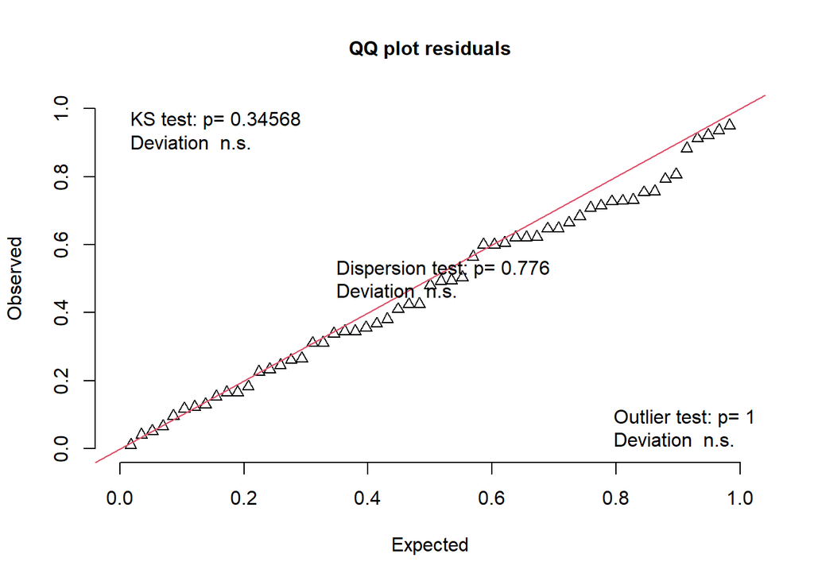

```
    Exact one-sample Kolmogorov-Smirnov test

data:  simulationOutput$scaledResiduals
D = 0.12106, p-value = 0.3457
alternative hypothesis: two-sided
```

```r
res3 <- simulateResiduals(mod_hydro)
testUniformity(res3) #uniformité des résidus (p-value plus de 0.05) Good!
```

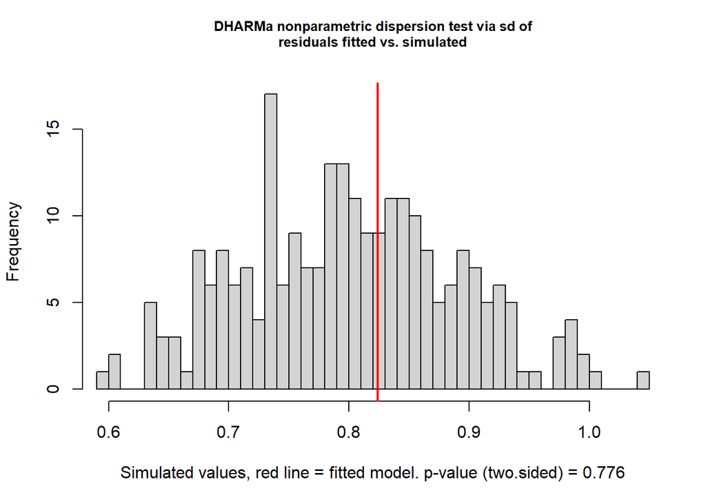

```
    DHARMa nonparametric dispersion test via sd of residuals fitted vs.
    simulated

data:  simulationOutput
dispersion = 1.0294, p-value = 0.776
alternative hypothesis: two.sided
```

```r
testDispersion(res3) #Pas de surdispersion (p-value plus de 0.05) Good!
```

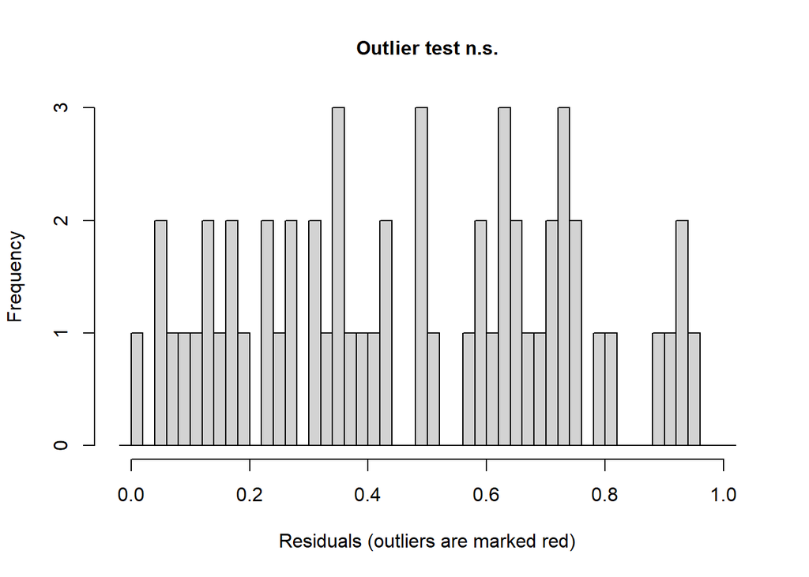

```
    DHARMa bootstrapped outlier test

data:  res3
outliers at both margin(s) = 0, observations = 57, p-value = 1
alternative hypothesis: two.sided
 percent confidence interval:
 0 0
sample estimates:
outlier frequency (expected: 0 )
                               0
```

```r
testOutliers(res3) #Zéro Outliers, good!
```

-Modèle avec juste les niveaux de débris

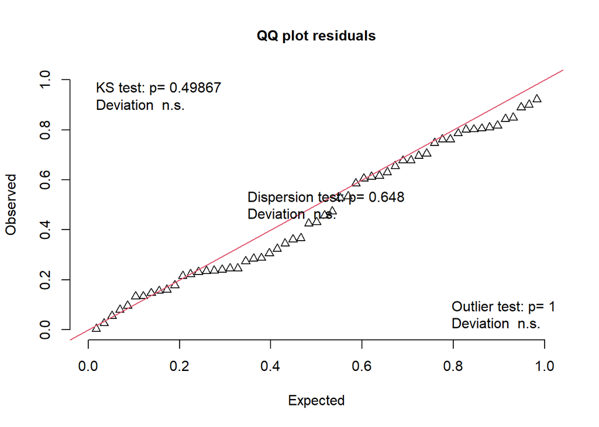

```
    Exact one-sample Kolmogorov-Smirnov test

data:  simulationOutput$scaledResiduals
D = 0.10693, p-value = 0.4987
alternative hypothesis: two-sided
```

```r
mod_debris <- glm(ambystoma ~ Debris_out+X+Y,family = binomial,data = df)
res4 <- simulateResiduals(mod_debris)
testUniformity(res4) #uniformité des résidus (p-value plus de 0.05) Good!
```

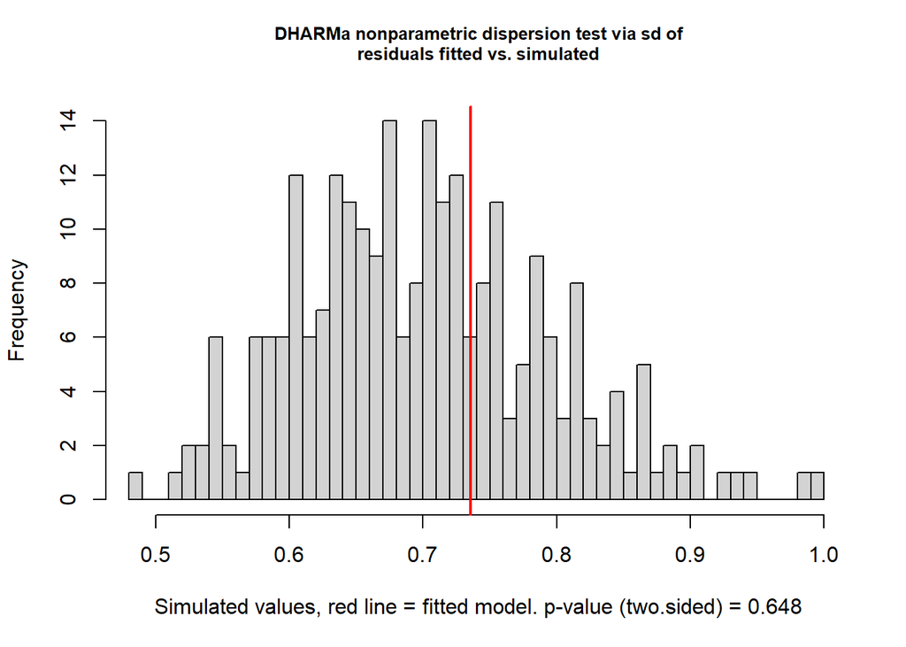

```
    DHARMa nonparametric dispersion test via sd of residuals fitted vs.
    simulated

data:  simulationOutput
dispersion = 1.0495, p-value = 0.648
alternative hypothesis: two.sided
```

```r
testDispersion(res4) #Pas de surdispersion (p-value plus de 0.05) Good!
```

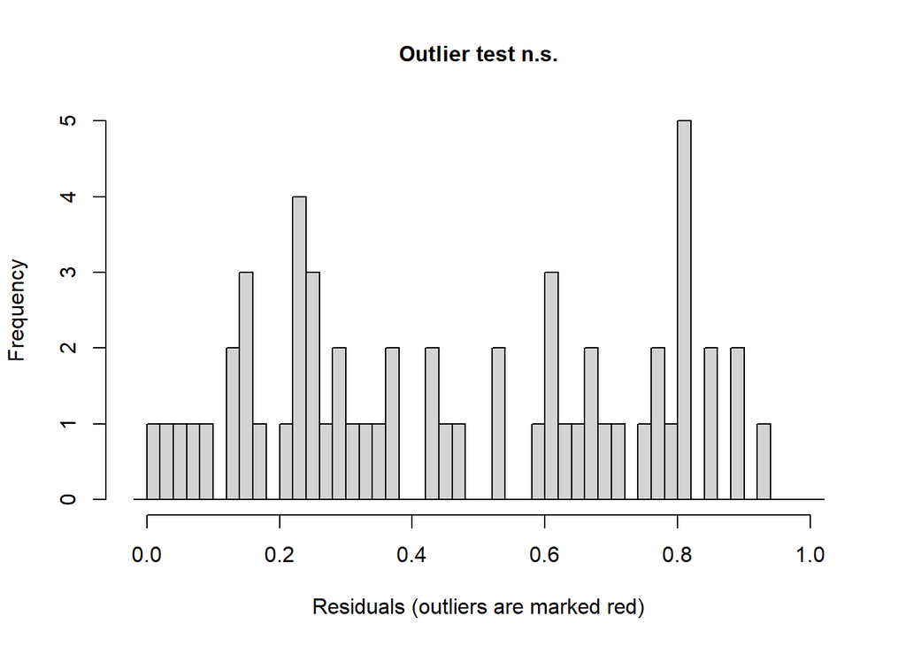

```
    DHARMa bootstrapped outlier test

data:  res4
outliers at both margin(s) = 0, observations = 57, p-value = 1
alternative hypothesis: two.sided
 percent confidence interval:
 0 0
sample estimates:
outlier frequency (expected: 0 )
                               0
```

```r
testOutliers(res4) #Zéro Outliers, good!
```

-Modèle Ouverture de la Canopée + Débris

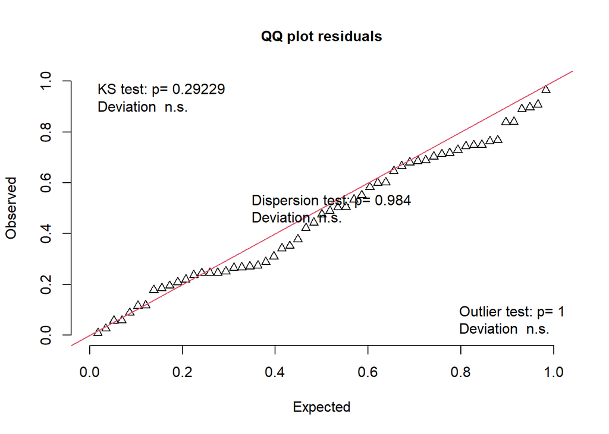

```
    Exact one-sample Kolmogorov-Smirnov test

data:  simulationOutput$scaledResiduals
D = 0.12691, p-value = 0.2923
alternative hypothesis: two-sided
```

```r
mod_can_deb <- glm(ambystoma ~ Ouverture+Debris_out+X+Y,family = binomial,data = df)
res5 <- simulateResiduals(mod_can_deb)
testUniformity(res5) #uniformité des résidus (p-value plus de 0.05) Good!
```

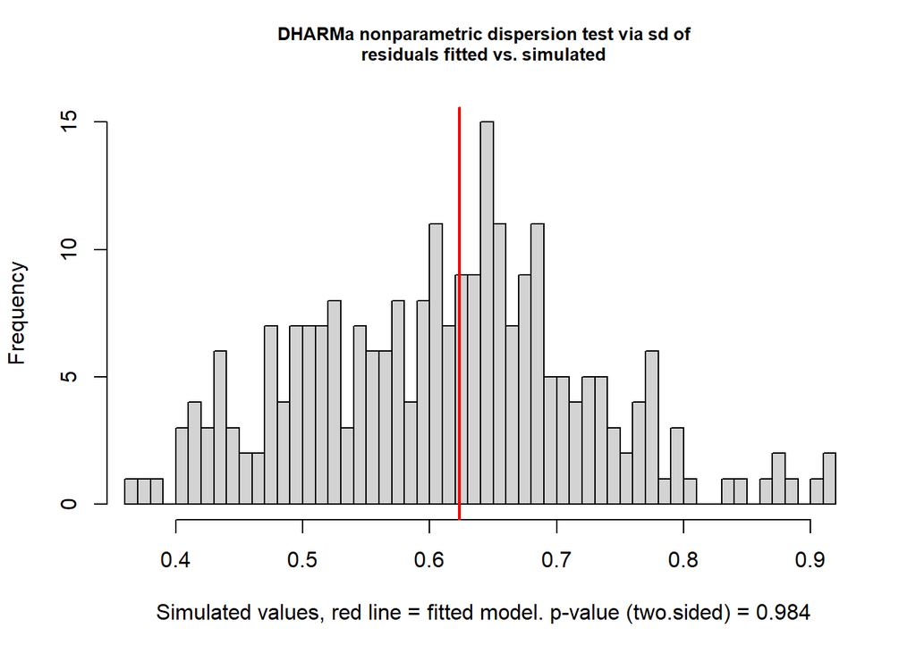

```
    DHARMa nonparametric dispersion test via sd of residuals fitted vs.
    simulated

data:  simulationOutput
dispersion = 1.0189, p-value = 0.984
alternative hypothesis: two.sided
```

```r
testDispersion(res5) #Pas de surdispersion (p-value plus de 0.05) Good!
```

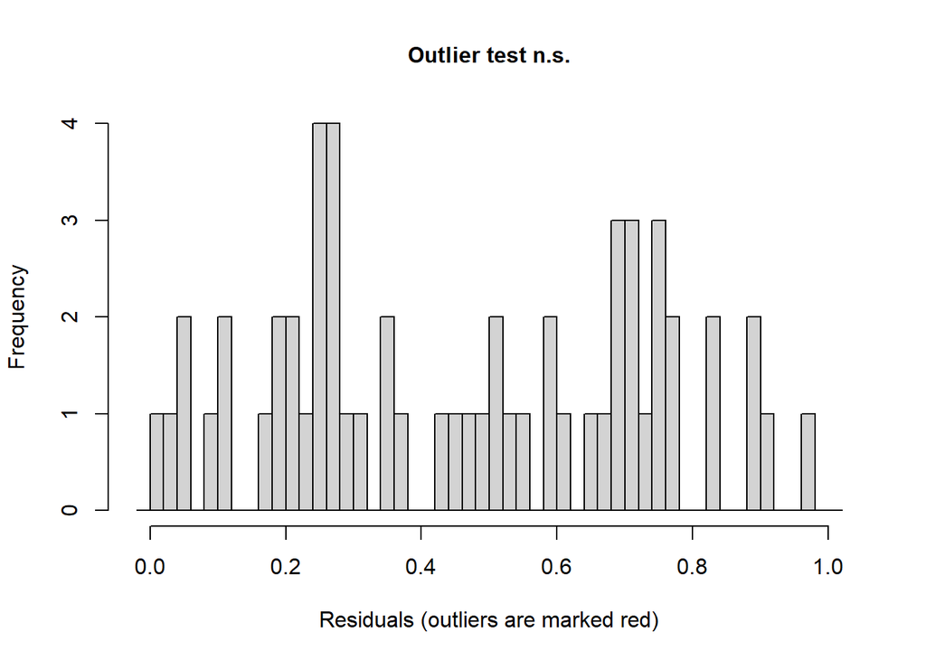

```
    DHARMa bootstrapped outlier test

data:  res5
outliers at both margin(s) = 0, observations = 57, p-value = 1
alternative hypothesis: two.sided
 percent confidence interval:
 0 0
sample estimates:
outlier frequency (expected: 0.000350877192982456 )
                                                  0
```

```r
testOutliers(res5) #Zéro Outliers, good!
```

-Modèle Ouverture de la Canopée + Hydropériode

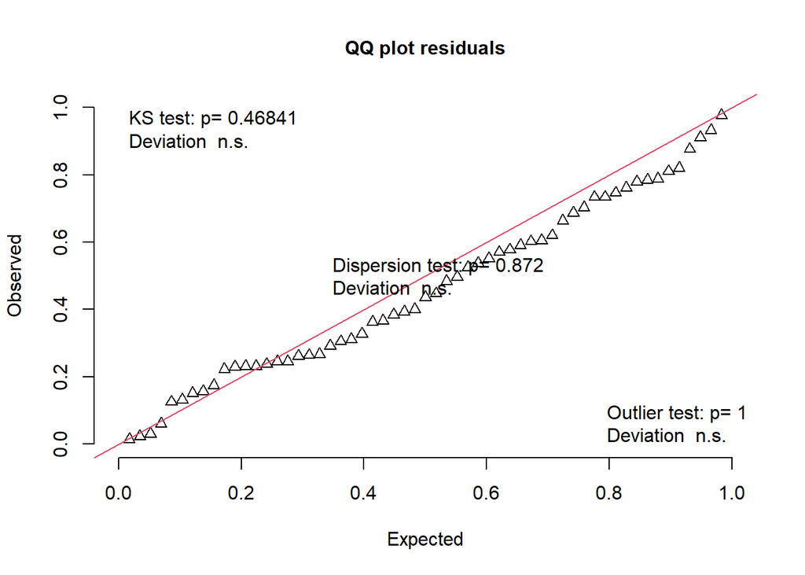

```
    Exact one-sample Kolmogorov-Smirnov test

data:  simulationOutput$scaledResiduals
D = 0.10951, p-value = 0.4684
alternative hypothesis: two-sided
```

```r
mod_can_hydro <- glm(ambystoma ~ Ouverture+Hydro+X+Y,family = binomial,data = df)
res6 <- simulateResiduals(mod_can_hydro)
testUniformity(res6) #uniformité des résidus (p-value plus de 0.05) Good!
```

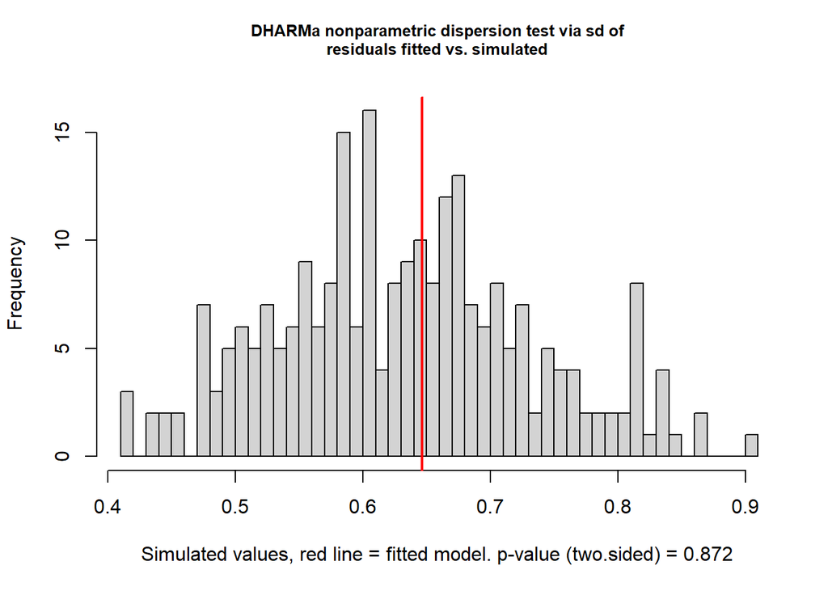

```
    DHARMa nonparametric dispersion test via sd of residuals fitted vs.
    simulated

data:  simulationOutput
dispersion = 1.0227, p-value = 0.872
alternative hypothesis: two.sided
```

```r
testDispersion(res6) #Pas de surdispersion (p-value plus de 0.05) Good!
```

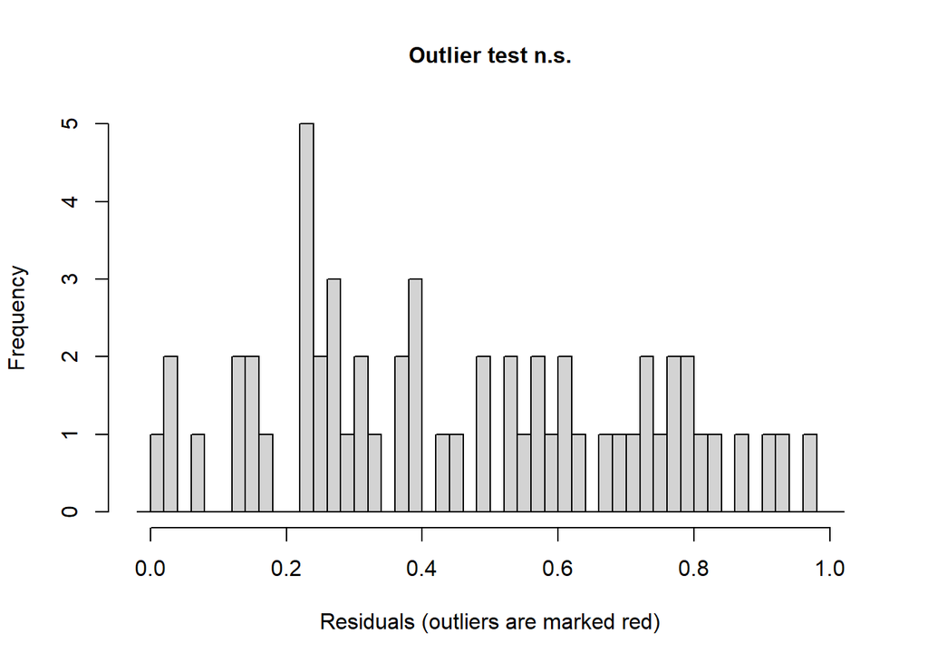

```
    DHARMa bootstrapped outlier test

data:  res6
outliers at both margin(s) = 0, observations = 57, p-value = 1
alternative hypothesis: two.sided
 percent confidence interval:
 0 0
sample estimates:
outlier frequency (expected: 0.000350877192982456 )
                                                  0
```

```r
testOutliers(res6) #Zéro Outliers, good!
```

-Modèle Hydropériode + Débris

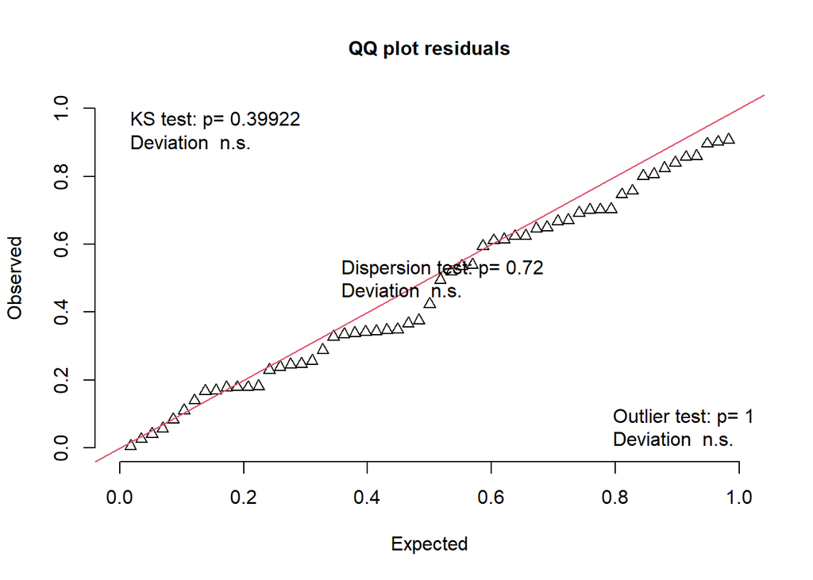

```
    Exact one-sample Kolmogorov-Smirnov test

data:  simulationOutput$scaledResiduals
D = 0.11576, p-value = 0.3992
alternative hypothesis: two-sided
```

```r
mod_hydro_deb <- glm(ambystoma ~ Debris_out+Hydro+X+Y,family = binomial,data = df)
res7 <- simulateResiduals(mod_hydro_deb)
testUniformity(res7) #uniformité des résidus (p-value plus de 0.05) Good!
```

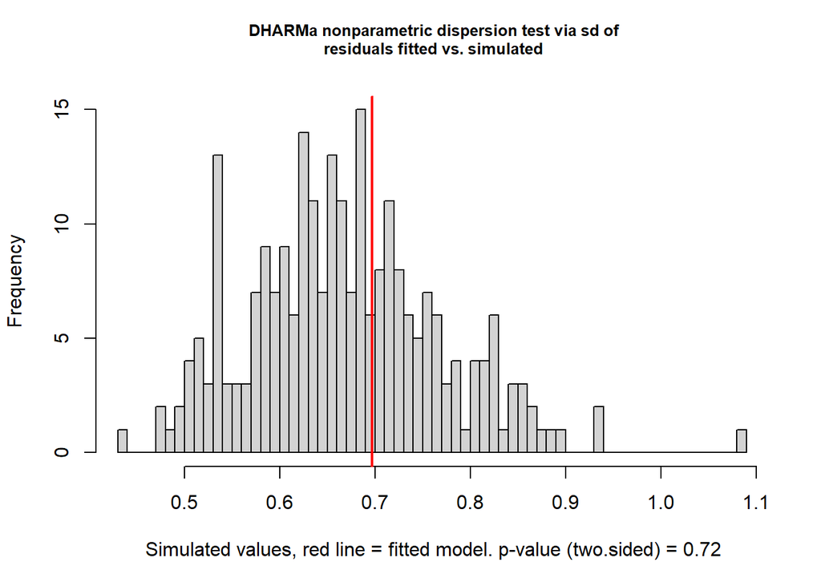

```
    DHARMa nonparametric dispersion test via sd of residuals fitted vs.
    simulated

data:  simulationOutput
dispersion = 1.0428, p-value = 0.72
alternative hypothesis: two.sided
```

```r
testDispersion(res7) #Pas de surdispersion (p-value plus de 0.05) Good!
```

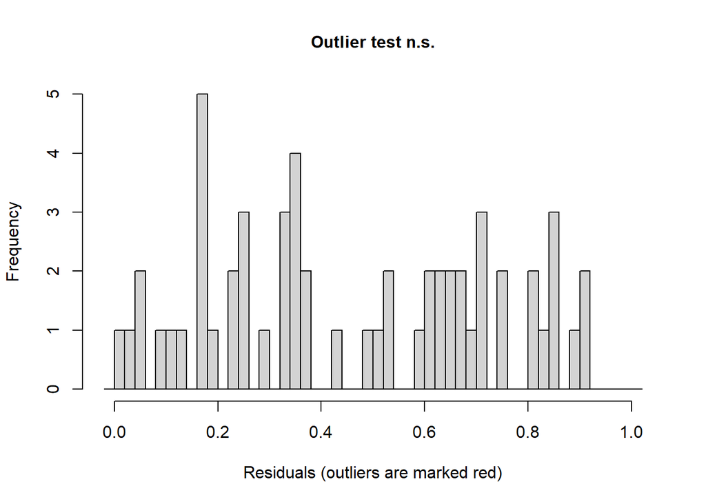

```
    DHARMa bootstrapped outlier test

data:  res7
outliers at both margin(s) = 0, observations = 57, p-value = 1
alternative hypothesis: two.sided
 percent confidence interval:
 0 0
sample estimates:
outlier frequency (expected: 0 )
                               0
```

```r
testOutliers(res7) #Zéro Outliers, good!
```

Maintenant, on est prêt pour l’analyse de l’AICc

```r
library(MuMIn)
AICc_tab <- AICc(mod0, mod_can, mod_hydro, mod_debris, mod_can_deb, mod_can_hydro, mod_hydro_deb, mod_test)
AICc_tab$Delta_AICc <- AICc_tab$AICc - min(AICc_tab$AICc)
AICc_tab$Poids <- exp(-0.5 * AICc_tab$Delta_AICc) / sum(exp(-0.5 * AICc_tab$Delta_AICc))
AICc_tab
```

```
              df     AICc Delta_AICc        Poids
mod0           1 81.07396 14.0940986 0.0002717599
mod_can        4 67.41940  0.4395418 0.2507464456
mod_hydro      4 75.25993  8.2800676 0.0049737762
mod_debris     5 71.07094  4.0910819 0.0403936329
mod_can_deb    6 67.49801  0.5181461 0.2410827132
mod_can_hydro  5 66.97986  0.0000000 0.3123777316
mod_hydro_deb  6 71.42509  4.4452315 0.0338384379
mod_test       7 68.95568  1.9758136 0.1163155027
```

Ce qui ressort ici c’est mod_can, mod_can_debris et mod_can_hydro le dernier ayant le AICc le plus bas et le poid le plus haut. Si on veux être parimonieux, on peut juste choisir mod_can. Donc la canopée aurait le plus grande influence sur la présence / abscence des salamandres du genre ambystomes

2.5 **Visualisation :**

Voici le la prédiction de la présence / abscence du modèle incluant que l’ouverture de la canopée:

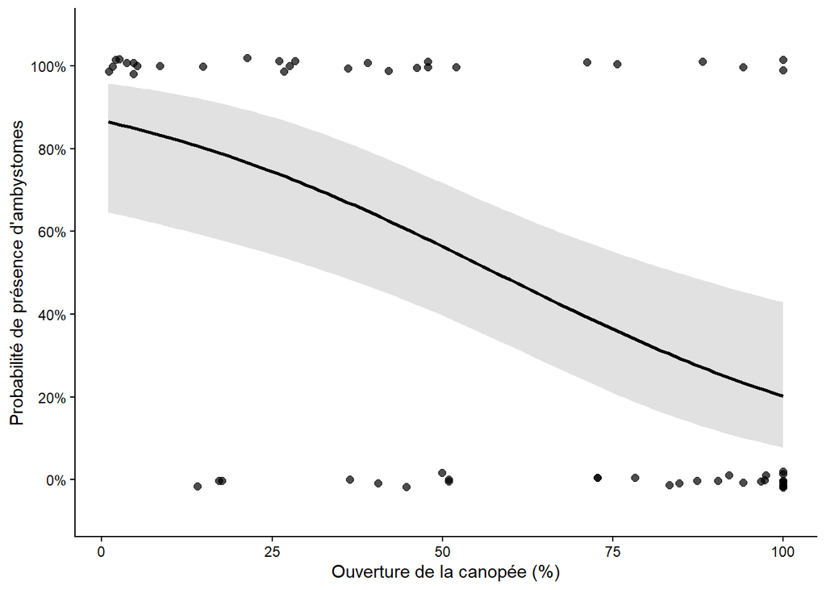

```r
library(ggeffects)
library(ggplot2)
pred_amby <- ggpredict(mod_can, terms = "Ouverture")
set.seed(123)
ggplot(pred_amby, aes(x = x, y = predicted)) +
  # Intervalle de confiance
geom_ribbon(aes(ymin = conf.low, ymax = conf.high),alpha = 0.15,colour = NA) +
  # Courbe prédite
geom_line(linewidth = 1) +
  # Observations réelles
geom_jitter(data = df,aes(x = Ouverture, y = ambystoma),width = 0,height = 0.02,alpha = 0.7,size = 2) +
scale_y_continuous(limits = c(-0.08, 1.08),breaks = seq(0, 1, 0.2),labels = function(x) paste0(x * 100, "%")) +
labs(x = "Ouverture de la canopée (%)",y = "Probabilité de présence d'ambystomes") + theme_classic()
```

Puisque le modèle ayant l’ouverture de la canopée ET l’hydrologie était intéressant aussi dans l’analyse AICc, voici une les prédiction de ce modèle aussi

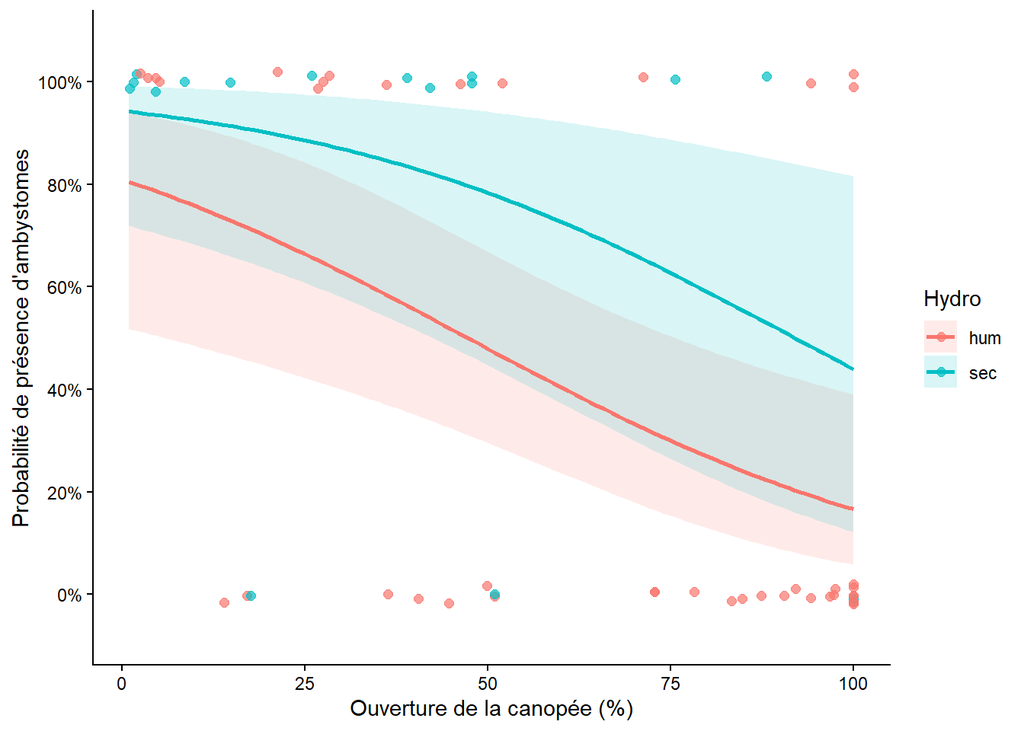

```r
pred_amby <- ggpredict(mod_can_hydro,terms = c("Ouverture", "Hydro"))
set.seed(123)
ggplot(pred_amby, aes(x = x, y = predicted, colour = group)) +
  # Intervalle de confiance
  geom_ribbon(aes(ymin = conf.low, ymax = conf.high, fill = group),alpha = 0.15,colour = NA) +
  # Courbes prédites
  geom_line(linewidth = 1) +
  # Observations réelles
  geom_jitter(data = df,aes(x = Ouverture, y = ambystoma, colour = Hydro),width = 0,height = 0.02, alpha = 0.7,size = 2) +
  scale_y_continuous(limits = c(-0.08, 1.08),breaks = seq(0, 1, 0.2),labels = function(x) paste0(x * 100, "%")) +
  labs(x = "Ouverture de la canopée (%)",y = "Probabilité de présence d'ambystomes",colour = "Hydro",fill = "Hydro") +
  theme_classic()
```

3.1 **Conclusion :**

Parmis toutes les espèces étudié dans ce projet, seul les ambystomes sont des espèces indicatrices d’un habitat précis. Celles-ci sont liées aux traitement NAT et CJ car ce type de traitement sylvicole mène à la création d’un habitat similaire: une canopée fermée (soit le critère le plus important à concidérer) et des étangs à hydropériode plus courte ce qui explique probablement la présence des ambystomes.